# Vorhersage der Schwere eines Unfalls in Frankreich

Idee dieses Projektes ist, Voraussagen über den Ausgang eines Vehrsunfalls in Frankreich treffen zu können. Die Labels sind also 1:' Unharmed' 2: 'Killed', 3: 'Injured hospitalized', 4: 'Slightly injured'.  
Wir benutzen hier französische Daten, weil die Unfälle in unserem Nachbarland sehr genau erfasst werden (siehe dazu weiter unten unsere Erklärung der einzelnen Features). Beispielsweise werden neben dem Alter und dem Geschlecht auch Fahrzeugkategorie und bis zu drei Sicherheitsausrüstungen(bspw. Helm bei Motorradfahrern oder Gürtel beim Auto oder Bus) genannt und sogar die Entfernung zum nächten Nottelefon auf der Autobahn. Die Anzahl der Features (über 40) läst uns gute Voraussagen treffen.

## Pakete einbinden

```python
import numpy as np
import pandas as pd

import seaborn as sns
import matplotlib.pyplot as plt
import matplotlib as mpl
%matplotlib inline
plt.rcParams['figure.dpi'] = 120

import warnings
warnings.filterwarnings('ignore')
```

# Daten einlesen und übersetzen

Der Datensatz liegt in vier Tabellen vor, die einzeln eingelesen werden. Die Spalten werden übersetzt.

```python
# Accident characteristics description
characteristics = pd.read_csv('caracteristiques-2019.csv')
characteristics.name = 'characteristics'
characteristics.rename(columns={'Num_Acc': 'ID_Acc', 'jour': 'Day', 'mois': 'Month', 'an': 'Year', 'hrmn': 'Time', 'lum': 'Light', 'dep': 'Department','com': 'Municipality','agg': 'Location'}, inplace=True)

#places where accidents occured
places = pd.read_csv('lieux-2019.csv')
places.name = 'places'
places.rename(columns={'Num_Acc': 'ID_Acc', "catr": "road_cat", "voie": "route_num", "v1": "road_index1", "v2": "road_index2", "circ": "traffic_regime", "nbv": "traffic_lanes", "vosp": "reserved_lane","pr":"upstream_terminal","pr1":"distance_to_upstream", "lartpc": "central_reservation_width", "larrout": "roadwidth_vehicles", "vma": "speed_limit"}, inplace=True)

# drivers / users at the time of the accident
drivers = pd.read_csv('usagers-2019.csv')
drivers.name = 'drivers'
drivers.rename(columns={'Num_Acc': 'ID_Acc', 'id_vehicule': 'ID_veh', 'num_veh': 'Vehicle_No', 'catu': 'User_category', 'grav': 'Severity', 'sexe': 'Gender_driver', 'an_nais': 'DOB_driver','trajet': 'Reason_for_travel','secu1': 'Safety_equip_1','secu2': 'Safety_equip_2','secu3': 'Safety_equip_3', 'locp': 'Ped_loc', 'actp': 'Ped_act', 'etatp': 'Ped_acc'}, inplace=True)

# vehicles met with an accident
vehicles = pd.read_csv('vehicules-2019.csv')
vehicles.name = 'vehicles'
vehicles.rename(columns={'Num_Acc': 'ID_Acc', 'id_vehicule': 'ID_veh', 'num_veh': 'Vehicle_No', 'catv': 'Vehicle_category', 'obs': 'Fix_Obst_st', 'obsm': 'Mov_Obst_st', 'choc': 'Shock_pt','manv': 'Maneuver','occutc': 'No.of_occupants', 'senc': 'Flow_Direction'}, inplace=True)

# Combine all the dataframes
datasets = [characteristics, places, vehicles, drivers]

# # Indexing the tables
# characteristics = characteristics.set_index('ID_Acc')
# places = places.set_index('ID_Acc')
# drivers = drivers.set_index('ID_veh')
# vehicles = vehicles.set_index('ID_veh')
```

### Data Visualization

```python
# display the size of datasets
for df in datasets:
    print("The Dataset ", df.name, " has",
          df.shape[0], "rows and", df.shape[1], "columns")
```

```
The Dataset  characteristics  has 58840 rows and 15 columns
The Dataset  places  has 58840 rows and 18 columns
The Dataset  vehicles  has 100710 rows and 11 columns
The Dataset  drivers  has 132977 rows and 15 columns
```

```python
# vehicles
print(vehicles.info())
vehicles.head(2)
```

```
<class 'pandas.core.frame.DataFrame'>
RangeIndex: 100710 entries, 0 to 100709
Data columns (total 11 columns):
 #   Column            Non-Null Count   Dtype
---  ------            --------------   -----
 0   ID_Acc            100710 non-null  int64
 1   ID_veh            100710 non-null  object
 2   Vehicle_No        100710 non-null  object
 3   Flow_Direction    100710 non-null  int64
 4   Vehicle_category  100710 non-null  int64
 5   Fix_Obst_st       100710 non-null  int64
 6   Mov_Obst_st       100710 non-null  int64
 7   Shock_pt          100710 non-null  int64
 8   Maneuver          100710 non-null  int64
 9   motor             100710 non-null  int64
 10  No.of_occupants   892 non-null     float64
dtypes: float64(1), int64(8), object(2)
memory usage: 8.5+ MB
None
```

|  | ID_Acc | ID_veh | Vehicle_No | Flow_Direction | Vehicle_category | Fix_Obst_st | Mov_Obst_st | Shock_pt | Maneuver | motor | No.of_occupants |
| --- | --- | --- | --- | --- | --- | --- | --- | --- | --- | --- | --- |
| 0 | 201900000001 | 138 306 524 | B01 | 2 | 7 | 0 | 2 | 5 | 23 | 1 | NaN |
| 1 | 201900000001 | 138 306 525 | A01 | 2 | 17 | 1 | 0 | 3 | 11 | 1 | NaN |

```python
# explore the first infos of dataset
for df in datasets:
    print(df.info())
```

```
<class 'pandas.core.frame.DataFrame'>
RangeIndex: 58840 entries, 0 to 58839
Data columns (total 15 columns):
 #   Column        Non-Null Count  Dtype
---  ------        --------------  -----
 0   ID_Acc        58840 non-null  object
 1   Day           58713 non-null  float64
 2   Month         58713 non-null  float64
 3   Year          58713 non-null  float64
 4   Time          58713 non-null  float64
 5   Light         58713 non-null  float64
 6   Department    58713 non-null  object
 7   Municipality  58713 non-null  object
 8   Location      58713 non-null  float64
 9   int           58713 non-null  float64
 10  atm           58713 non-null  float64
 11  col           58713 non-null  float64
 12  adr           58286 non-null  object
 13  lat           58713 non-null  float64
 14  long          58713 non-null  float64
dtypes: float64(11), object(4)
memory usage: 6.7+ MB
None
<class 'pandas.core.frame.DataFrame'>
RangeIndex: 58840 entries, 0 to 58839
Data columns (total 18 columns):
 #   Column                     Non-Null Count  Dtype
---  ------                     --------------  -----
 0   ID_Acc                     58840 non-null  object
 1   road_cat                   58814 non-null  float64
 2   route_num                  55879 non-null  object
 3   road_index1                48068 non-null  float64
 4   road_index2                4167 non-null   object
 5   traffic_regime             55669 non-null  float64
 6   traffic_lanes              58164 non-null  float64
 7   reserved_lane              58145 non-null  float64
 8   prof                       58800 non-null  float64
 9   upstream_terminal          51517 non-null  float64
 10  distance_to_upstream       51215 non-null  float64
 11  plan                       58803 non-null  float64
```

[output cut: 36 more lines]

```
 3   place              132977 non-null  int64
 4   User_category      132977 non-null  int64
 5   Severity           132977 non-null  int64
 6   Gender_driver      132977 non-null  int64
 7   DOB_driver         132977 non-null  int64
 8   Reason_for_travel  132977 non-null  int64
 9   Safety_equip_1     132977 non-null  int64
 10  Safety_equip_2     132977 non-null  int64
 11  Safety_equip_3     132977 non-null  int64
 12  Ped_loc            132977 non-null  int64
 13  Ped_act            132977 non-null  object
 14  Ped_acc            132977 non-null  int64
dtypes: int64(12), object(3)
memory usage: 15.2+ MB
None
```

```python
characteristics
```

|  | ID_Acc | Day | Month | Year | Time | Light | Department | Municipality | Location | int | atm | col | adr | lat | long |
| --- | --- | --- | --- | --- | --- | --- | --- | --- | --- | --- | --- | --- | --- | --- | --- |
| 0 | 201900000001 | 30.0 | 11.0 | 2019.0 | 0.062500 | 4.0 | 93 | 93053 | 1.0 | 1.0 | 1.0 | 2.0 | AUTOROUTE A3 | 488962100.0 | 24701200.0 |
| 1 | 201900000002 | 30.0 | 11.0 | 2019.0 | 0.118056 | 3.0 | 93 | 93066 | 1.0 | 1.0 | 1.0 | 6.0 | AUTOROUTE A1 | 489307000.0 | 23688000.0 |
| 2 | 201900000003 | 28.0 | 11.0 | 2019.0 | 0.635417 | 1.0 | 92 | 92036 | 1.0 | 1.0 | 1.0 | 4.0 | AUTOROUTE A86 | 489358718.0 | 23191744.0 |
| 3 | 201900000004 | 30.0 | 11.0 | 2019.0 | 0.847222 | 5.0 | 94 | 94069 | 1.0 | 1.0 | 1.0 | 4.0 | A4 | 488173295.0 | 24281502.0 |
| 4 | 201900000005 | 30.0 | 11.0 | 2019.0 | 0.166667 | 3.0 | 94 | 94028 | 1.0 | 1.0 | 1.0 | 2.0 | A86 INT | 487763620.0 | 24332540.0 |
| ... | ... | ... | ... | ... | ... | ... | ... | ... | ... | ... | ... | ... | ... | ... | ... |
| 58835 | 201900058836 | 30.0 | 11.0 | 2019.0 | 0.375000 | 1.0 | 69 | 69288 | 1.0 | 1.0 | 5.0 | 2.0 | A43 13.029 A 15.971 | 456666600.0 | 50561200.0 |
| 58836 | 201900058837 | 27.0 | 11.0 | 2019.0 | 0.326389 | 1.0 | 67 | 67482 | 1.0 | 1.0 | 8.0 | 4.0 | Autoroute A.35 | 485769000.0 | 77269000.0 |
| 58837 | 201900058838 | 30.0 | 11.0 | 2019.0 | 0.111806 | 4.0 | 94 | 94021 | 1.0 | 1.0 | 1.0 | 6.0 | AUTOROUTE A6A | 487717000.0 | 23457600.0 |
| 58838 | 201900058839 | 30.0 | 11.0 | 2019.0 | 0.638889 | 1.0 | 78 | 78640 | 1.0 | 1.0 | 1.0 | 7.0 | A86 EXT | 487772890.0 | 22237590.0 |
| 58839 | 201900058840 | 29.0 | 11.0 | 2019.0 | 0.868056 | 3.0 | 92 | 92047 | 1.0 | 1.0 | 1.0 | 2.0 | A13 | 488351236.0 | 21751101.0 |

58840 rows × 15 columns

```python
places
```

|  | ID_Acc | road_cat | route_num | road_index1 | road_index2 | traffic_regime | traffic_lanes | reserved_lane | prof | upstream_terminal | distance_to_upstream | plan | central_reservation_width | roadwidth_vehicles | surf | infra | situ | speed_limit |
| --- | --- | --- | --- | --- | --- | --- | --- | --- | --- | --- | --- | --- | --- | --- | --- | --- | --- | --- |
| 0 | 201900000001 | 1.0 | 3 | 0.0 | NaN | 3.0 | 10.0 | 0.0 | 1.0 | 6.0 | 900.0 | 2.0 | NaN | NaN | 1.0 | 2.0 | 1.0 | 70.0 |
| 1 | 201900000002 | 1.0 | 1 | 0.0 | NaN | 1.0 | 2.0 | 0.0 | 4.0 | 3.0 | 845.0 | 2.0 | NaN | NaN | 1.0 | 0.0 | 1.0 | 70.0 |
| 2 | 201900000003 | 1.0 | 86 | 0.0 | NaN | 3.0 | 8.0 | 0.0 | 1.0 | 10.0 | 500.0 | 3.0 | NaN | NaN | 1.0 | 0.0 | 1.0 | 90.0 |
| 3 | 201900000004 | 1.0 | 4 | 0.0 | NaN | 3.0 | 5.0 | 0.0 | 1.0 | 2.0 | 299.0 | 1.0 | NaN | NaN | 1.0 | 0.0 | 1.0 | 90.0 |
| 4 | 201900000005 | 1.0 | 86 | 0.0 | INT | 1.0 | 3.0 | 0.0 | 1.0 | 41.0 | 0.0 | 3.0 | NaN | NaN | 1.0 | 2.0 | 1.0 | 90.0 |
| ... | ... | ... | ... | ... | ... | ... | ... | ... | ... | ... | ... | ... | ... | ... | ... | ... | ... | ... |
| 58835 | 201900058836 | 1.0 | 43 | 0.0 | NaN | 1.0 | 3.0 | 0.0 | 1.0 | 15.0 | 500.0 | 1.0 | NaN | NaN | 2.0 | 3.0 | 1.0 | 130.0 |
| 58836 | 201900058837 | 1.0 | 35 | 0.0 | NaN | 1.0 | 2.0 | 0.0 | 1.0 | 303.0 | 282.0 | 1.0 | NaN | NaN | 2.0 | 0.0 | 1.0 | 90.0 |
| 58837 | 201900058838 | 1.0 | 6 | 0.0 | A | 3.0 | 3.0 | 0.0 | 1.0 | 5.0 | 199.0 | 1.0 | NaN | NaN | 1.0 | 0.0 | 1.0 | 90.0 |
| 58838 | 201900058839 | 1.0 | 86 | 0.0 | NaN | 1.0 | 1.0 | 0.0 | 1.0 | 59.0 | 99.0 | 3.0 | NaN | NaN | 1.0 | 0.0 | 1.0 | 50.0 |
| 58839 | 201900058840 | 1.0 | 13 | 0.0 | NaN | 1.0 | 3.0 | 0.0 | 1.0 | 6.0 | 699.0 | 1.0 | NaN | NaN | 1.0 | 0.0 | 2.0 | 110.0 |

58840 rows × 18 columns

```python
drivers
```

|  | ID_Acc | ID_veh | Vehicle_No | place | User_category | Severity | Gender_driver | DOB_driver | Reason_for_travel | Safety_equip_1 | Safety_equip_2 | Safety_equip_3 | Ped_loc | Ped_act | Ped_acc |
| --- | --- | --- | --- | --- | --- | --- | --- | --- | --- | --- | --- | --- | --- | --- | --- |
| 0 | 201900000001 | 138 306 524 | B01 | 2 | 2 | 4 | 2 | 2002 | 0 | 1 | 0 | -1 | -1 | -1 | -1 |
| 1 | 201900000001 | 138 306 524 | B01 | 1 | 1 | 4 | 2 | 1993 | 5 | 1 | 0 | -1 | -1 | -1 | -1 |
| 2 | 201900000001 | 138 306 525 | A01 | 1 | 1 | 1 | 1 | 1959 | 0 | 1 | 0 | -1 | -1 | -1 | -1 |
| 3 | 201900000002 | 138 306 523 | A01 | 1 | 1 | 4 | 2 | 1994 | 0 | 1 | 0 | -1 | -1 | -1 | -1 |
| 4 | 201900000003 | 138 306 520 | A01 | 1 | 1 | 1 | 1 | 1996 | 0 | 1 | 0 | -1 | -1 | 0 | -1 |
| ... | ... | ... | ... | ... | ... | ... | ... | ... | ... | ... | ... | ... | ... | ... | ... |
| 132972 | 201900058837 | 137 982 135 | C01 | 1 | 1 | 4 | 2 | 1988 | 1 | 1 | 0 | -1 | -1 | -1 | -1 |
| 132973 | 201900058838 | 137 982 132 | A01 | 1 | 1 | 4 | 1 | 1998 | 9 | 1 | 0 | -1 | -1 | -1 | -1 |
| 132974 | 201900058839 | 137 982 131 | A01 | 1 | 1 | 3 | 1 | 1979 | 0 | 2 | 0 | -1 | -1 | -1 | -1 |
| 132975 | 201900058840 | 137 982 129 | B01 | 1 | 1 | 4 | 1 | 1974 | 0 | 1 | 0 | -1 | -1 | 0 | -1 |
| 132976 | 201900058840 | 137 982 130 | A01 | 1 | 1 | 1 | 1 | 1971 | 0 | 1 | -1 | -1 | 0 | 0 | -1 |

132977 rows × 15 columns

```python
vehicles
```

|  | ID_Acc | ID_veh | Vehicle_No | Flow_Direction | Vehicle_category | Fix_Obst_st | Mov_Obst_st | Shock_pt | Maneuver | motor | No.of_occupants |
| --- | --- | --- | --- | --- | --- | --- | --- | --- | --- | --- | --- |
| 0 | 201900000001 | 138 306 524 | B01 | 2 | 7 | 0 | 2 | 5 | 23 | 1 | NaN |
| 1 | 201900000001 | 138 306 525 | A01 | 2 | 17 | 1 | 0 | 3 | 11 | 1 | NaN |
| 2 | 201900000002 | 138 306 523 | A01 | 1 | 7 | 4 | 0 | 1 | 0 | 1 | NaN |
| 3 | 201900000003 | 138 306 520 | A01 | 1 | 7 | 0 | 2 | 1 | 2 | 1 | NaN |
| 4 | 201900000003 | 138 306 521 | B01 | 1 | 7 | 1 | 0 | 4 | 2 | 1 | NaN |
| ... | ... | ... | ... | ... | ... | ... | ... | ... | ... | ... | ... |
| 100705 | 201900058837 | 137 982 135 | C01 | 1 | 7 | 0 | 2 | 1 | 2 | 1 | NaN |
| 100706 | 201900058838 | 137 982 132 | A01 | 2 | 7 | 3 | 0 | 1 | 21 | 0 | NaN |
| 100707 | 201900058839 | 137 982 131 | A01 | 2 | 33 | 0 | 0 | 7 | 1 | 1 | NaN |
| 100708 | 201900058840 | 137 982 129 | B01 | 1 | 10 | 0 | 2 | 4 | 0 | 2 | NaN |
| 100709 | 201900058840 | 137 982 130 | A01 | 1 | 10 | 0 | 2 | 1 | 0 | 1 | NaN |

100710 rows × 11 columns

```python
characteristics = characteristics[characteristics['Day'].notna()]
characteristics = characteristics[characteristics['Month'].notna()]
characteristics = characteristics[characteristics['Year'].notna()]
characteristics
#characteristics['Day'] = characteristics['Day'].drop
```

|  | ID_Acc | Day | Month | Year | Time | Light | Department | Municipality | Location | int | atm | col | adr | lat | long |
| --- | --- | --- | --- | --- | --- | --- | --- | --- | --- | --- | --- | --- | --- | --- | --- |
| 0 | 201900000001 | 30.0 | 11.0 | 2019.0 | 0.062500 | 4.0 | 93 | 93053 | 1.0 | 1.0 | 1.0 | 2.0 | AUTOROUTE A3 | 488962100.0 | 24701200.0 |
| 1 | 201900000002 | 30.0 | 11.0 | 2019.0 | 0.118056 | 3.0 | 93 | 93066 | 1.0 | 1.0 | 1.0 | 6.0 | AUTOROUTE A1 | 489307000.0 | 23688000.0 |
| 2 | 201900000003 | 28.0 | 11.0 | 2019.0 | 0.635417 | 1.0 | 92 | 92036 | 1.0 | 1.0 | 1.0 | 4.0 | AUTOROUTE A86 | 489358718.0 | 23191744.0 |
| 3 | 201900000004 | 30.0 | 11.0 | 2019.0 | 0.847222 | 5.0 | 94 | 94069 | 1.0 | 1.0 | 1.0 | 4.0 | A4 | 488173295.0 | 24281502.0 |
| 4 | 201900000005 | 30.0 | 11.0 | 2019.0 | 0.166667 | 3.0 | 94 | 94028 | 1.0 | 1.0 | 1.0 | 2.0 | A86 INT | 487763620.0 | 24332540.0 |
| ... | ... | ... | ... | ... | ... | ... | ... | ... | ... | ... | ... | ... | ... | ... | ... |
| 58835 | 201900058836 | 30.0 | 11.0 | 2019.0 | 0.375000 | 1.0 | 69 | 69288 | 1.0 | 1.0 | 5.0 | 2.0 | A43 13.029 A 15.971 | 456666600.0 | 50561200.0 |
| 58836 | 201900058837 | 27.0 | 11.0 | 2019.0 | 0.326389 | 1.0 | 67 | 67482 | 1.0 | 1.0 | 8.0 | 4.0 | Autoroute A.35 | 485769000.0 | 77269000.0 |
| 58837 | 201900058838 | 30.0 | 11.0 | 2019.0 | 0.111806 | 4.0 | 94 | 94021 | 1.0 | 1.0 | 1.0 | 6.0 | AUTOROUTE A6A | 487717000.0 | 23457600.0 |
| 58838 | 201900058839 | 30.0 | 11.0 | 2019.0 | 0.638889 | 1.0 | 78 | 78640 | 1.0 | 1.0 | 1.0 | 7.0 | A86 EXT | 487772890.0 | 22237590.0 |
| 58839 | 201900058840 | 29.0 | 11.0 | 2019.0 | 0.868056 | 3.0 | 92 | 92047 | 1.0 | 1.0 | 1.0 | 2.0 | A13 | 488351236.0 | 21751101.0 |

58713 rows × 15 columns

```python
characteristics['Day'] = characteristics['Day'].astype(int)
characteristics['Month'] = characteristics['Month'].astype(int)
characteristics['Year'] = characteristics['Year'].astype(int)
characteristics
```

|  | ID_Acc | Day | Month | Year | Time | Light | Department | Municipality | Location | int | atm | col | adr | lat | long |
| --- | --- | --- | --- | --- | --- | --- | --- | --- | --- | --- | --- | --- | --- | --- | --- |
| 0 | 201900000001 | 30 | 11 | 2019 | 0.062500 | 4.0 | 93 | 93053 | 1.0 | 1.0 | 1.0 | 2.0 | AUTOROUTE A3 | 488962100.0 | 24701200.0 |
| 1 | 201900000002 | 30 | 11 | 2019 | 0.118056 | 3.0 | 93 | 93066 | 1.0 | 1.0 | 1.0 | 6.0 | AUTOROUTE A1 | 489307000.0 | 23688000.0 |
| 2 | 201900000003 | 28 | 11 | 2019 | 0.635417 | 1.0 | 92 | 92036 | 1.0 | 1.0 | 1.0 | 4.0 | AUTOROUTE A86 | 489358718.0 | 23191744.0 |
| 3 | 201900000004 | 30 | 11 | 2019 | 0.847222 | 5.0 | 94 | 94069 | 1.0 | 1.0 | 1.0 | 4.0 | A4 | 488173295.0 | 24281502.0 |
| 4 | 201900000005 | 30 | 11 | 2019 | 0.166667 | 3.0 | 94 | 94028 | 1.0 | 1.0 | 1.0 | 2.0 | A86 INT | 487763620.0 | 24332540.0 |
| ... | ... | ... | ... | ... | ... | ... | ... | ... | ... | ... | ... | ... | ... | ... | ... |
| 58835 | 201900058836 | 30 | 11 | 2019 | 0.375000 | 1.0 | 69 | 69288 | 1.0 | 1.0 | 5.0 | 2.0 | A43 13.029 A 15.971 | 456666600.0 | 50561200.0 |
| 58836 | 201900058837 | 27 | 11 | 2019 | 0.326389 | 1.0 | 67 | 67482 | 1.0 | 1.0 | 8.0 | 4.0 | Autoroute A.35 | 485769000.0 | 77269000.0 |
| 58837 | 201900058838 | 30 | 11 | 2019 | 0.111806 | 4.0 | 94 | 94021 | 1.0 | 1.0 | 1.0 | 6.0 | AUTOROUTE A6A | 487717000.0 | 23457600.0 |
| 58838 | 201900058839 | 30 | 11 | 2019 | 0.638889 | 1.0 | 78 | 78640 | 1.0 | 1.0 | 1.0 | 7.0 | A86 EXT | 487772890.0 | 22237590.0 |
| 58839 | 201900058840 | 29 | 11 | 2019 | 0.868056 | 3.0 | 92 | 92047 | 1.0 | 1.0 | 1.0 | 2.0 | A13 | 488351236.0 | 21751101.0 |

58713 rows × 15 columns

```python
cols=["Year","Month","Day"]
characteristics['Date'] = characteristics[cols].apply(lambda x: '-'.join(x.values.astype(str)), axis="columns")
characteristics
```

|  | ID_Acc | Day | Month | Year | Time | Light | Department | Municipality | Location | int | atm | col | adr | lat | long | Date |
| --- | --- | --- | --- | --- | --- | --- | --- | --- | --- | --- | --- | --- | --- | --- | --- | --- |
| 0 | 201900000001 | 30 | 11 | 2019 | 0.062500 | 4.0 | 93 | 93053 | 1.0 | 1.0 | 1.0 | 2.0 | AUTOROUTE A3 | 488962100.0 | 24701200.0 | 2019-11-30 |
| 1 | 201900000002 | 30 | 11 | 2019 | 0.118056 | 3.0 | 93 | 93066 | 1.0 | 1.0 | 1.0 | 6.0 | AUTOROUTE A1 | 489307000.0 | 23688000.0 | 2019-11-30 |
| 2 | 201900000003 | 28 | 11 | 2019 | 0.635417 | 1.0 | 92 | 92036 | 1.0 | 1.0 | 1.0 | 4.0 | AUTOROUTE A86 | 489358718.0 | 23191744.0 | 2019-11-28 |
| 3 | 201900000004 | 30 | 11 | 2019 | 0.847222 | 5.0 | 94 | 94069 | 1.0 | 1.0 | 1.0 | 4.0 | A4 | 488173295.0 | 24281502.0 | 2019-11-30 |
| 4 | 201900000005 | 30 | 11 | 2019 | 0.166667 | 3.0 | 94 | 94028 | 1.0 | 1.0 | 1.0 | 2.0 | A86 INT | 487763620.0 | 24332540.0 | 2019-11-30 |
| ... | ... | ... | ... | ... | ... | ... | ... | ... | ... | ... | ... | ... | ... | ... | ... | ... |
| 58835 | 201900058836 | 30 | 11 | 2019 | 0.375000 | 1.0 | 69 | 69288 | 1.0 | 1.0 | 5.0 | 2.0 | A43 13.029 A 15.971 | 456666600.0 | 50561200.0 | 2019-11-30 |
| 58836 | 201900058837 | 27 | 11 | 2019 | 0.326389 | 1.0 | 67 | 67482 | 1.0 | 1.0 | 8.0 | 4.0 | Autoroute A.35 | 485769000.0 | 77269000.0 | 2019-11-27 |
| 58837 | 201900058838 | 30 | 11 | 2019 | 0.111806 | 4.0 | 94 | 94021 | 1.0 | 1.0 | 1.0 | 6.0 | AUTOROUTE A6A | 487717000.0 | 23457600.0 | 2019-11-30 |
| 58838 | 201900058839 | 30 | 11 | 2019 | 0.638889 | 1.0 | 78 | 78640 | 1.0 | 1.0 | 1.0 | 7.0 | A86 EXT | 487772890.0 | 22237590.0 | 2019-11-30 |
| 58839 | 201900058840 | 29 | 11 | 2019 | 0.868056 | 3.0 | 92 | 92047 | 1.0 | 1.0 | 1.0 | 2.0 | A13 | 488351236.0 | 21751101.0 | 2019-11-29 |

58713 rows × 16 columns

# Exploratory Data Analysis and Visualisations

## Is there a trend in number of accidents according to Monthly seasonlaity?

```python
characteristics['Month'].unique()
```

```
array([11,  9,  7,  2,  1,  5,  4,  8,  6, 10,  3, 12])
```

```python
# merge 'characteristics' and 'drivers' dataframe
merge_caracUsagers = pd.concat([characteristics , drivers])
```

```python
# Function to split 'Severity'
def split_Severity(X):
    class_dummies=pd.get_dummies(X["Severity"],prefix ="Severity")
    X = X.join(class_dummies )
    return X
```

```python
merge_caracUsagers = split_Severity(merge_caracUsagers)
merge_caracUsagers
```

|  | ID_Acc | Day | Month | Year | Time | Light | Department | Municipality | Location | int | ... | Safety_equip_1 | Safety_equip_2 | Safety_equip_3 | Ped_loc | Ped_act | Ped_acc | Severity_1.0 | Severity_2.0 | Severity_3.0 | Severity_4.0 |
| --- | --- | --- | --- | --- | --- | --- | --- | --- | --- | --- | --- | --- | --- | --- | --- | --- | --- | --- | --- | --- | --- |
| 0 | 201900000001 | 30.0 | 11.0 | 2019.0 | 0.062500 | 4.0 | 93 | 93053 | 1.0 | 1.0 | ... | NaN | NaN | NaN | NaN | NaN | NaN | 0 | 0 | 0 | 0 |
| 0 | 201900000001 | 30.0 | 11.0 | 2019.0 | 0.062500 | 4.0 | 93 | 93053 | 1.0 | 1.0 | ... | NaN | NaN | NaN | NaN | NaN | NaN | 0 | 0 | 0 | 1 |
| 0 | 201900000001 | NaN | NaN | NaN | NaN | NaN | NaN | NaN | NaN | NaN | ... | 1.0 | 0.0 | -1.0 | -1.0 | -1 | -1.0 | 0 | 0 | 0 | 0 |
| 0 | 201900000001 | NaN | NaN | NaN | NaN | NaN | NaN | NaN | NaN | NaN | ... | 1.0 | 0.0 | -1.0 | -1.0 | -1 | -1.0 | 0 | 0 | 0 | 1 |
| 1 | 201900000002 | 30.0 | 11.0 | 2019.0 | 0.118056 | 3.0 | 93 | 93066 | 1.0 | 1.0 | ... | NaN | NaN | NaN | NaN | NaN | NaN | 0 | 0 | 0 | 0 |
| ... | ... | ... | ... | ... | ... | ... | ... | ... | ... | ... | ... | ... | ... | ... | ... | ... | ... | ... | ... | ... | ... |
| 132972 | 201900058837 | NaN | NaN | NaN | NaN | NaN | NaN | NaN | NaN | NaN | ... | 1.0 | 0.0 | -1.0 | -1.0 | -1 | -1.0 | 0 | 0 | 0 | 1 |
| 132973 | 201900058838 | NaN | NaN | NaN | NaN | NaN | NaN | NaN | NaN | NaN | ... | 1.0 | 0.0 | -1.0 | -1.0 | -1 | -1.0 | 0 | 0 | 0 | 1 |
| 132974 | 201900058839 | NaN | NaN | NaN | NaN | NaN | NaN | NaN | NaN | NaN | ... | 2.0 | 0.0 | -1.0 | -1.0 | -1 | -1.0 | 0 | 0 | 1 | 0 |
| 132975 | 201900058840 | NaN | NaN | NaN | NaN | NaN | NaN | NaN | NaN | NaN | ... | 1.0 | 0.0 | -1.0 | -1.0 | 0 | -1.0 | 0 | 0 | 0 | 1 |
| 132976 | 201900058840 | NaN | NaN | NaN | NaN | NaN | NaN | NaN | NaN | NaN | ... | 1.0 | -1.0 | -1.0 | 0.0 | 0 | -1.0 | 1 | 0 | 0 | 0 |

309116 rows × 34 columns

```python
dfmonth_grav = merge_caracUsagers[['Month', 'Severity_1.0', 'Severity_2.0', 'Severity_3.0', 'Severity_4.0']]
```

```python
# Creating 4 DataFrames for the 4 'grav'
dfmonth_grav_1 = dfmonth_grav [[ 'Month' , 'Severity_1.0' ]]
dfmonth_grav_2 = dfmonth_grav [[ 'Month', 'Severity_2.0' ]]
dfmonth_grav_3 = dfmonth_grav [[ 'Month' , 'Severity_3.0' ]]
dfmonth_grav_4 = dfmonth_grav [[ 'Month' , 'Severity_4.0' ]]
```

```python
# Group by month on each DataFrame
dfmonth_grav_1 = dfmonth_grav_1.groupby([ 'Month']).sum ()
dfmonth_grav_2 = dfmonth_grav_2.groupby([ 'Month']).sum ()
dfmonth_grav_3 = dfmonth_grav_3.groupby([ 'Month']).sum ()
dfmonth_grav_4 = dfmonth_grav_4.groupby([ 'Month']).sum ()
```

```python
# Dataframe with severity per month
dfgravPerMonth = dfmonth_grav_1 [[ 'Severity_1.0' ]]
dfgravPerMonth [ 'Severity_4.0' ] = dfmonth_grav_4 [[ 'Severity_4.0' ]]
dfgravPerMonth [ 'Severity_3.0' ] = dfmonth_grav_3 [[ 'Severity_3.0' ]]
dfgravPerMonth [ 'Severity_2.0 ' ] = dfmonth_grav_2 [['Severity_2.0' ]]
```

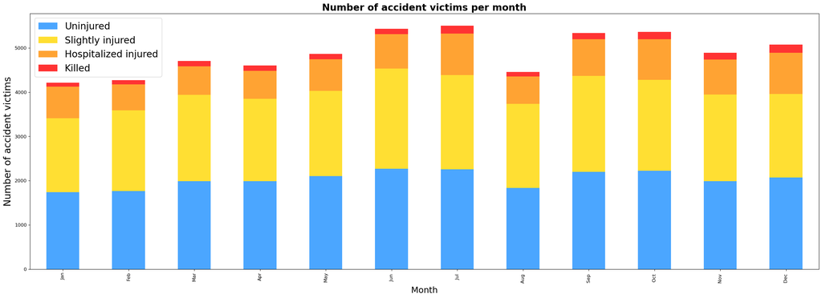

```python
# Number of accident victims per month
ax  =  dfgravPerMonth . plot ( kind = 'bar' ,  stacked = True ,  figsize = ( 30 , 10 ),  color = [ 'dodgerblue' ,  'gold' ,  'darkorange', 'red' ], alpha = 0.8);

ax . legend ([ "Uninjured" ,  "Slightly injured" ,  "Hospitalized injured" ,  "Killed" ],  fontsize = 20 );
ax . set_title ( "Number of accident victims per month" ,
             fontdict = { 'fontsize' :  20 ,  'fontweight' :  'bold' });
ax . set_ylabel ( "Number of accident victims"  ,
              fontdict = { 'fontsize' :20, 'fontweight': 'medium' });
ax . set_xlabel ( "Month"  ,
              fontdict = { 'fontsize' :  18 ,  'fontweight' : 'medium' });

plt . xticks ([ 0 , 1 , 2 , 3 , 4 , 5 , 6 , 7 , 8 , 9 , 10 , 11 ], [ 'Jan' ,  'Feb' ,  'Mar' ,  'Apr' ,  'May' ,  ' Jun ' , ' Jul ' ,  ' Aug ' ,  ' Sep ' ,  ' Oct ' ,  ' Nov ' ,  ' Dec ' ] );
```

#### Findings:

• A sharp rise is observed in the months of June, July, Septemeber and October

• There is steep reduction in no.of accidents for the month of January, February & August.

• July 2019 reported the highest number of accidents

# Does the Day of the week influences the series of accidents for each Month?

```python
dfheatMap1 = characteristics[['Date','ID_Acc']]
```

```python
# Number of accidents grouped by date
dfheatMap1 = dfheatMap1.groupby (['Date']).count ()
dfheatMap1
```

| Date | ID_Acc |
| --- | --- |
| 2019-1-1 | 104 |
| 2019-1-10 | 141 |
| 2019-1-11 | 187 |
| 2019-1-12 | 126 |
| 2019-1-13 | 119 |
| ... | ... |
| 2019-9-5 | 160 |
| 2019-9-6 | 239 |
| 2019-9-7 | 202 |
| 2019-9-8 | 135 |
| 2019-9-9 | 162 |

365 rows × 1 columns

```python
# Creating list for the DataFrame
data = []
for i in range(len(dfheatMap1)):
    data.append([ dfheatMap1.index[i],dfheatMap1.ID_Acc.iloc[i]])

# DataFrame creation
dfheatMap1=pd.DataFrame(data,columns=['Date','count_acc'])
dfheatMap1.head ()
```

|  | Date | count_acc |
| --- | --- | --- |
| 0 | 2019-1-1 | 104 |
| 1 | 2019-1-10 | 141 |
| 2 | 2019-1-11 | 187 |
| 3 | 2019-1-12 | 126 |
| 4 | 2019-1-13 | 119 |

```python
dfheatMap1["Date"] = pd.to_datetime(dfheatMap1["Date"], errors='coerce')
```

```python
# Adding week day column
dfheatMap1["DayOfWeek"] = dfheatMap1["Date"].dt.day_name()
dfheatMap1
```

|  | Date | count_acc | DayOfWeek |
| --- | --- | --- | --- |
| 0 | 2019-01-01 | 104 | Tuesday |
| 1 | 2019-01-10 | 141 | Thursday |
| 2 | 2019-01-11 | 187 | Friday |
| 3 | 2019-01-12 | 126 | Saturday |
| 4 | 2019-01-13 | 119 | Sunday |
| ... | ... | ... | ... |
| 360 | 2019-09-05 | 160 | Thursday |
| 361 | 2019-09-06 | 239 | Friday |
| 362 | 2019-09-07 | 202 | Saturday |
| 363 | 2019-09-08 | 135 | Sunday |
| 364 | 2019-09-09 | 162 | Monday |

365 rows × 3 columns

```python
# Adding month column
dfheatMap1['Month']= dfheatMap1.apply(lambda row:row.Date.month,axis = 1)
dfheatMap1 = dfheatMap1.drop(['Date'],axis = 1)

dfheatMap1
```

|  | count_acc | DayOfWeek | Month |
| --- | --- | --- | --- |
| 0 | 104 | Tuesday | 1 |
| 1 | 141 | Thursday | 1 |
| 2 | 187 | Friday | 1 |
| 3 | 126 | Saturday | 1 |
| 4 | 119 | Sunday | 1 |
| ... | ... | ... | ... |
| 360 | 160 | Thursday | 9 |
| 361 | 239 | Friday | 9 |
| 362 | 202 | Saturday | 9 |
| 363 | 135 | Sunday | 9 |
| 364 | 162 | Monday | 9 |

365 rows × 3 columns

```python
# Creating pivot with the groupby and unstack
dfheatMap1 = dfheatMap1.groupby(['Month','DayOfWeek']).sum().unstack()

# Deleting multiple indexes
dfheatMap1 = dfheatMap1.count_acc

# Changing column order
dfheatMap1 = dfheatMap1[['Monday' , 'Tuesday' , 'Wednesday' , 'Thursday' , 'Friday' , 'Saturday' , 'Sunday' ]]

dfheatMap1
```

| DayOfWeek Month | Monday | Tuesday | Wednesday | Thursday | Friday | Saturday | Sunday |
| --- | --- | --- | --- | --- | --- | --- | --- |
| 1 | 560 | 689 | 665 | 714 | 685 | 507 | 394 |
| 2 | 581 | 594 | 585 | 649 | 781 | 598 | 483 |
| 3 | 540 | 610 | 606 | 643 | 887 | 754 | 667 |
| 4 | 670 | 752 | 622 | 672 | 756 | 632 | 502 |
| 5 | 644 | 654 | 787 | 789 | 865 | 590 | 533 |
| 6 | 661 | 706 | 724 | 725 | 880 | 891 | 843 |
| 7 | 822 | 910 | 882 | 765 | 796 | 717 | 612 |
| 8 | 498 | 534 | 567 | 709 | 826 | 793 | 527 |
| 9 | 858 | 676 | 749 | 712 | 886 | 713 | 745 |
| 10 | 633 | 851 | 794 | 911 | 819 | 698 | 656 |
| 11 | 651 | 714 | 675 | 691 | 969 | 739 | 450 |
| 12 | 862 | 835 | 648 | 705 | 808 | 595 | 622 |

```python
# Changing type of index into string
dfheatMap1.index = dfheatMap1.index.astype('str')

# Replacing numbers by month names
dfheatMap1.index= dfheatMap1.index.map({ '1' : 'January' , '2' : 'February' , '3' : 'March' , '4' : 'April' , '5' : 'May' ,
                                        '6' :  'June' , '7' : 'July'  , '8' :  'August' , '9' :'September', '10': 'October',
                                        '11' : 'November' ,  '12' : 'December' })
```

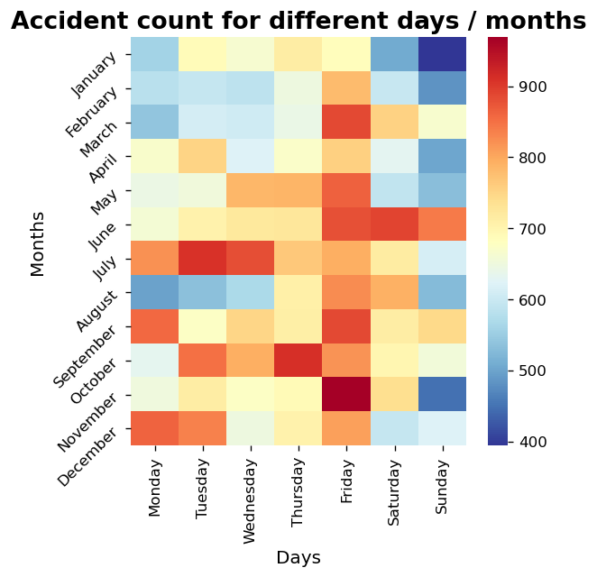

```python
# HeatMap
import  seaborn  as  sns

fig,ax  = plt.subplots ( figsize = (5,5 ))
ax= sns . heatmap ( dfheatMap1 , cmap = "RdYlBu_r" )

ax.set_title("Accident count for different days / months" ,  fontdict = { 'fontsize' :  16 ,  'fontweight' :  'bold' });
ax.set_ylabel("Months"  ,  fontdict = { 'fontsize' :  12 ,  'fontweight' :  'medium' });
ax.set_xlabel("Days"  ,  fontdict = { 'fontsize' :  12 ,'fontweight' :  'medium' });
plt.yticks(rotation = 45 );
```

### Findings:

• Sunday of January reported less number of accidents

# Does Lighting Conditions have any impact on Severity of accidents?

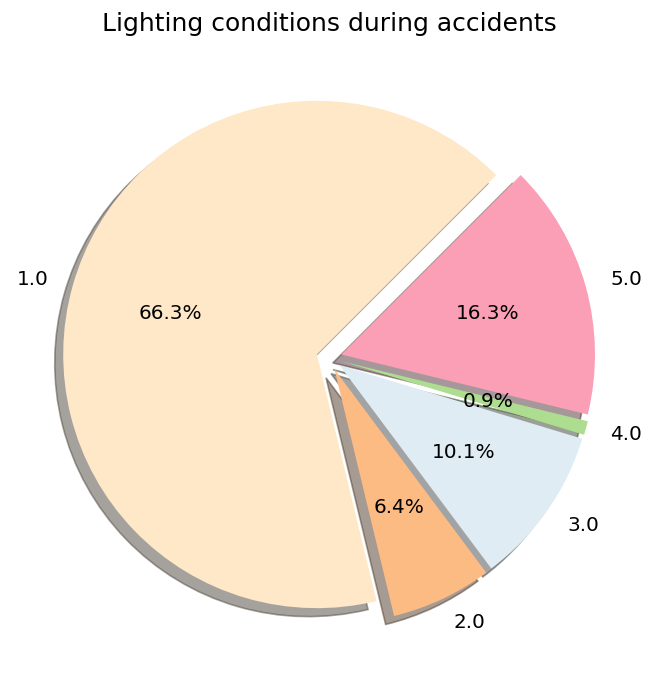

```python
#pie chart of lighting conditions during accidents
#group df by lighting, select acc_id, count number of accidents and plot a pie chart
by_lighting = characteristics.groupby('Light')['ID_Acc'].count()
lighting_pie = by_lighting.plot.pie(autopct='%1.1f%%',figsize=(7,7),startangle=45,
                                                    explode=[0.05,0.05,0.05,0.05,0.05],
                                                    fontsize=12,shadow=True,
                                                    colors=['#fee8c8','#fdbb84','#e0ecf4','#addd8e','#fa9fb5'])

lighting_pie.set_ylabel('')
lighting_pie.set_title('Lighting conditions during accidents', fontsize=15);
```

Light:

- 1. Full day
- 1. Twilight or dawn
- 1. Night without public lighting
- 1. Night with public lighting not on
- 1. Night with public lighting on

### Findings:

- Majority of accidents happen under good lighting conditions (either 'Full Day' or at 'Night with public lighting on').

# Good Lighting conditions reports to have high number of accidents, then would other factors play an important role with Lighting?

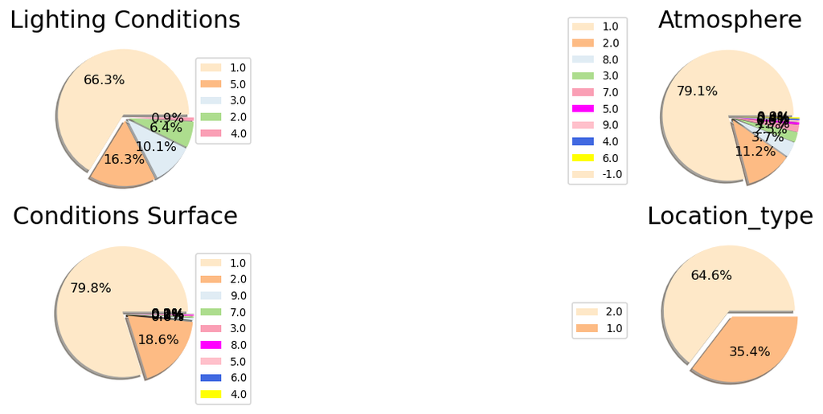

```python
colors=['#fee8c8','#fdbb84','#e0ecf4','#addd8e','#fa9fb5', 'magenta', 'pink', 'royalblue', 'yellow']

#Plot summary of the number of accidents all values for each environmental condition
fig4,ax4 = plt.subplots(2,2,figsize=(15,5))
ax4[0,0].pie(characteristics['Light'].value_counts(), shadow=True, autopct='%1.1f%%', explode=[0.05,0.05,0.05,0.05,0.05], colors = colors)
ax4[0,0].set_title('Lighting Conditions',fontsize=18)
pieleg0 = ax4[0,0].legend(labels=characteristics['Light'].value_counts().index,bbox_to_anchor=(0.9,0.6), fontsize=8,loc="center left")
ax4[0,1].pie(characteristics['atm'].value_counts(), shadow=True, autopct='%1.1f%%', explode=[0.05,0.05,0.05,0.05,0.05,0.05,0.05,0.05,0.05,0.05], colors = colors)
ax4[0,1].set_title('Atmosphere',fontsize=18)
pieleg1 = ax4[0,1].legend(labels=characteristics['atm'].value_counts().index,bbox_to_anchor=(-0.1,0.6), fontsize=8,loc="center right")
ax4[1,0].pie(places['surf'].value_counts(), shadow=True, autopct='%1.1f%%', explode=[0.05,0.05,0.05,0.05,0.05,0.05,0.05,0.05,0.05], colors = colors)
ax4[1,0].set_title('Conditions Surface',fontsize=18)
pieleg2 = ax4[1,0].legend(labels=places['surf'].value_counts().index,bbox_to_anchor=(0.9,0.9), fontsize=8,loc="best")
ax4[1,1].pie(characteristics['Location'].value_counts(), shadow=True, autopct='%1.1f%%', explode=[0.05,0.05], colors = colors)
ax4[1,1].set_title('Location_type',fontsize=18)
pieleg2 = ax4[1,1].legend(labels=characteristics['Location'].value_counts().index,bbox_to_anchor=(-0.1,0.6), fontsize=8,loc="best")
```

### Findings:

Atmospheric conditions: 1. Normal 2. Light rain 3. Heavy rain 4. Snow. hail 5. Fog. smoke 6. Strong wind. storm 7. Dazzling weather 8. Cloudy weather 9. Other

Location: 1. Outside Urban agglomeration 2. In built-up areas

Light: 1. Full day 2. Twilight or dawn 3. Night without public lighting 4. Night with public lighting not on 5. Night with public lighting on

Surface condition: 1. Normal 2. Wet 3. Puddles 4. Flooded 5. Snowy 6. Mud 7. Icy 8. Fat. oil 9. Other

## Did Gender feature observed any bias in the severity of accident types?

We would like to know the relative proportions of accident severities in Males and Females

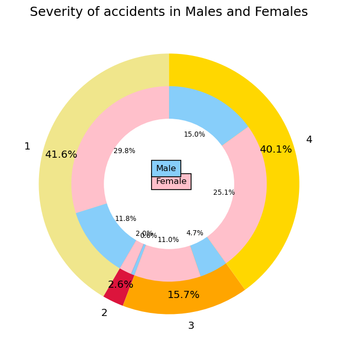

```python
#nested donut chart

#group df by accident severity (for outer ring) and count number of accidents
by_severity = drivers.groupby('Severity')['ID_Acc'].count()

#group df by severity and gender (for inner ring) and count number of accidents
by_severity_gender = drivers.groupby(['Severity','Gender_driver'])['ID_Acc'].count()


colors=['khaki' , 'crimson','orange', 'gold'] #for outer ring
colors_gender = ['pink','lightskyblue', 'pink','lightskyblue','pink','lightskyblue','pink','lightskyblue'] #for inner ring

#create pie plots and mask the centre with a circle to make donuts
ax = by_severity.plot.pie(autopct='%1.1f%%',pctdistance=0.86,
                        colors=colors, startangle=90,frame=True,figsize=(7,7),fontsize=12)

ax = by_severity_gender.plot.pie(labels=None,autopct='%1.1f%%',pctdistance=0.57,fontsize=8,
                                 colors=colors_gender,radius=0.75,startangle=90)

centre_circle = plt.Circle((0,0),0.5,color='black', fc='white',linewidth=0)

ax.add_artist(centre_circle)
ax.text(-0.1,0, 'Female',bbox={'facecolor': 'pink','pad':5})
ax.text(-0.1,0.1, 'Male',bbox={'facecolor': 'lightskyblue', 'pad':5})
ax.set_title('Severity of accidents in Males and Females',fontsize=15)
ax.set_ylabel('');
```

### Findings:

# Which road users are highly prone to severity of road accidents?

```python
drivers['User_category'].nunique()
```

```
3
```

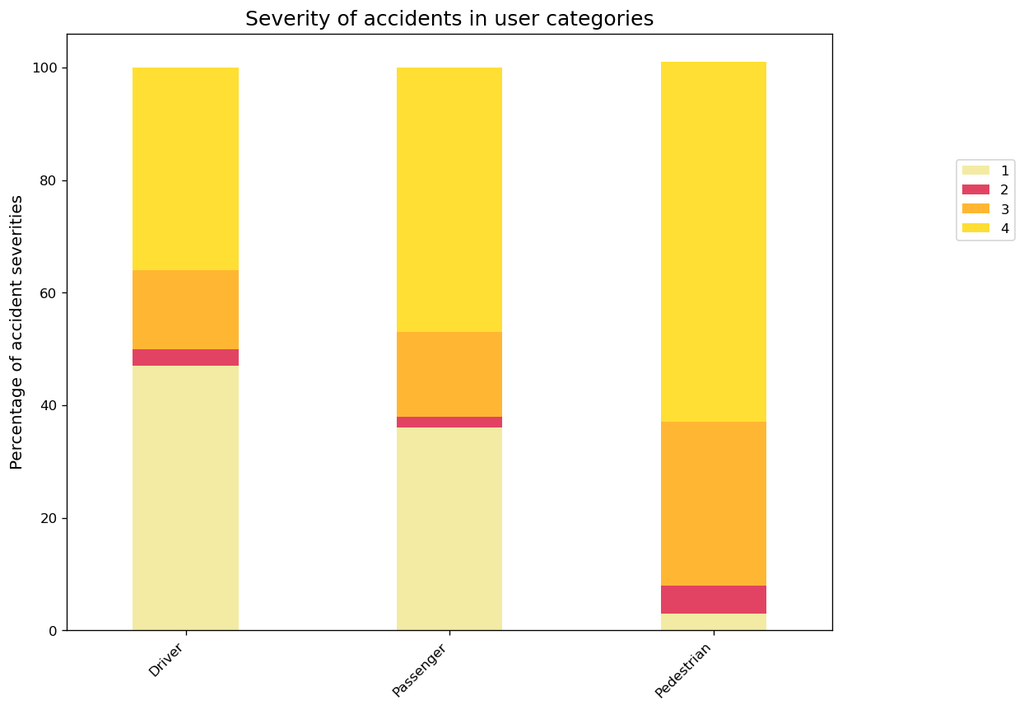

```python
#stacked bar chart of accident severity in different user categories

#group df by user_category and severity, select acc_id, count the number of accidents
user_sev = drivers.groupby(['User_category','Severity'])['ID_Acc'].count()

#Convert count values into percentage and plot a stacked bar chart
user_sev_pct = user_sev.groupby(level=0).apply(lambda x: round(100 * x / x.sum()))

colors=['khaki' , 'crimson','orange', 'gold' ]
labels=['Driver','Passenger','Pedestrian']

ax=user_sev_pct.unstack().plot.bar(stacked=True,figsize=(10,8), color=colors,width=0.4, alpha = 0.8)
ax.legend(loc=9, bbox_to_anchor=(1.2,0.8))
ax.set_xlabel('')
ax.set_xticklabels(labels=labels,rotation=45,ha='right')
ax.set_ylabel('Percentage of accident severities', fontsize=12)
ax.set_title('Severity of accidents in user categories', fontsize=15);
```

Severity:

- 1. Unharmed
- 1. Killed
- 1. Injured hospitalized
- 1. Slightly injured

### Findings:

- As expected, Pedestrians are more likely to incur injuries or get hospitalized during accidents as compared to users who are Drivers or Passengers.

# Distribution of Drivers involved in accidents by Age

```python
#characteristics.reset_index(drop=True, inplace=True)
#drivers.reset_index(drop=True, inplace=True)
merge_caracUsagers1 = pd.concat([characteristics, drivers], axis=1)
merge_caracUsagers1.loc[merge_caracUsagers1["Date"].notna()]
merge_caracUsagers1
```

|  | ID_Acc | Day | Month | Year | Time | Light | Department | Municipality | Location | int | ... | Severity | Gender_driver | DOB_driver | Reason_for_travel | Safety_equip_1 | Safety_equip_2 | Safety_equip_3 | Ped_loc | Ped_act | Ped_acc |
| --- | --- | --- | --- | --- | --- | --- | --- | --- | --- | --- | --- | --- | --- | --- | --- | --- | --- | --- | --- | --- | --- |
| 0 | 201900000001 | 30.0 | 11.0 | 2019.0 | 0.062500 | 4.0 | 93 | 93053 | 1.0 | 1.0 | ... | 4 | 2 | 2002 | 0 | 1 | 0 | -1 | -1 | -1 | -1 |
| 1 | 201900000002 | 30.0 | 11.0 | 2019.0 | 0.118056 | 3.0 | 93 | 93066 | 1.0 | 1.0 | ... | 4 | 2 | 1993 | 5 | 1 | 0 | -1 | -1 | -1 | -1 |
| 2 | 201900000003 | 28.0 | 11.0 | 2019.0 | 0.635417 | 1.0 | 92 | 92036 | 1.0 | 1.0 | ... | 1 | 1 | 1959 | 0 | 1 | 0 | -1 | -1 | -1 | -1 |
| 3 | 201900000004 | 30.0 | 11.0 | 2019.0 | 0.847222 | 5.0 | 94 | 94069 | 1.0 | 1.0 | ... | 4 | 2 | 1994 | 0 | 1 | 0 | -1 | -1 | -1 | -1 |
| 4 | 201900000005 | 30.0 | 11.0 | 2019.0 | 0.166667 | 3.0 | 94 | 94028 | 1.0 | 1.0 | ... | 1 | 1 | 1996 | 0 | 1 | 0 | -1 | -1 | 0 | -1 |
| ... | ... | ... | ... | ... | ... | ... | ... | ... | ... | ... | ... | ... | ... | ... | ... | ... | ... | ... | ... | ... | ... |
| 132972 | NaN | NaN | NaN | NaN | NaN | NaN | NaN | NaN | NaN | NaN | ... | 4 | 2 | 1988 | 1 | 1 | 0 | -1 | -1 | -1 | -1 |
| 132973 | NaN | NaN | NaN | NaN | NaN | NaN | NaN | NaN | NaN | NaN | ... | 4 | 1 | 1998 | 9 | 1 | 0 | -1 | -1 | -1 | -1 |
| 132974 | NaN | NaN | NaN | NaN | NaN | NaN | NaN | NaN | NaN | NaN | ... | 3 | 1 | 1979 | 0 | 2 | 0 | -1 | -1 | -1 | -1 |
| 132975 | NaN | NaN | NaN | NaN | NaN | NaN | NaN | NaN | NaN | NaN | ... | 4 | 1 | 1974 | 0 | 1 | 0 | -1 | -1 | 0 | -1 |
| 132976 | NaN | NaN | NaN | NaN | NaN | NaN | NaN | NaN | NaN | NaN | ... | 1 | 1 | 1971 | 0 | 1 | -1 | -1 | 0 | 0 | -1 |

132977 rows × 31 columns

```python
# Retrieving the lines of those killed
dfageDeaths  =  merge_caracUsagers1 . drop ( merge_caracUsagers1 [ merge_caracUsagers1 . Severity !=  2 ] . index )

# Creating a victim's age column
dfageDeaths [ 'killed_age' ] = dfageDeaths [ 'Year' ] - dfageDeaths [ 'DOB_driver' ] . fillna ( 0.0 ) . astype ( int )
```

```python
dfageDeaths = dfageDeaths [[ 'ID_Acc' , 'killed_age' ]]
```

```python
# Killed group by age
dfageDeaths = dfageDeaths . groupby ([ 'killed_age' ]) . count ()
```

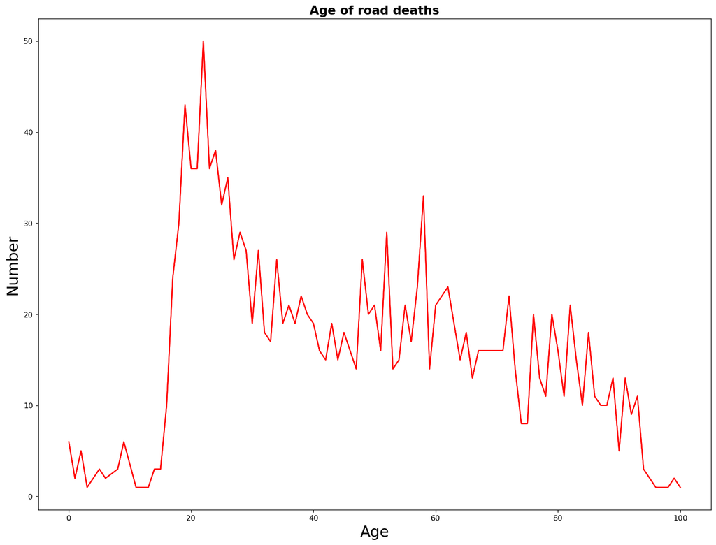

```python
fig ,  ax  =  plt . subplots ( figsize = ( 16,12))
ax . plot(dfageDeaths, color = 'r')

ax . set_title ( "Age of road deaths" ,
             fontdict = { 'fontsize' :  16 ,  'fontweight' :  'bold' })
ax . set_ylabel ( "Number"  ,
              fontdict = { 'fontsize' :  20 ,  'fontweight' :  'medium' })
ax.set_xlabel ( "Age"  ,
              fontdict = { 'fontsize' :  20 ,  'fontweight' : 'medium' })
plt.show ()
```

### Findings:

- Maximum Drivers with age of range 16-26 have reported death in road accidents

# Are there high accidents in Highway?

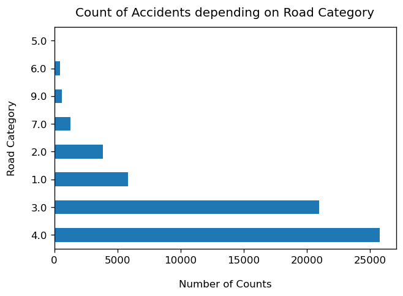

```python
places['road_cat'].value_counts().plot(kind='barh');
plt.xlabel("Number of Counts", labelpad=14)
plt.ylabel("Road Category", labelpad=14)
plt.title("Count of Accidents depending on Road Category", y=1.02);
```

### Findings:

top road Category leading to road traffic accidents

- 1. Communal roads
- 1. Departmental road
- 1. Highway
- 1. National road
- 1. Urban metropolis roads

**Highway road category did not result into highest numbers**

# Which type of Vehicle has great severity in road accident?

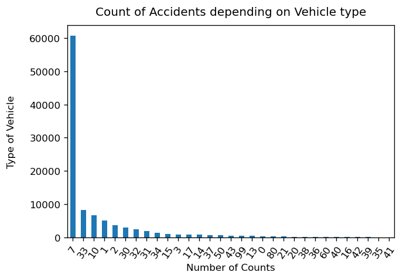

```python
vehicles['Vehicle_category'].value_counts().plot(kind='bar');
plt.xlabel("Number of Counts", fontsize=10)
plt.ylabel("Type of Vehicle", labelpad=14)
plt.title("Count of Accidents depending on Vehicle type", y=1.02);
plt.xticks(rotation=55);
```

# Is there any correlation with other characteristics of road users with severity reported?

```python
df123 = pd.concat([characteristics, places, drivers], axis=1)
#df123 = merge_caracUsagers.loc[merge_caracUsagers["Day"].notna()]
df123
```

|  | ID_Acc | Day | Month | Year | Time | Light | Department | Municipality | Location | int | ... | Severity | Gender_driver | DOB_driver | Reason_for_travel | Safety_equip_1 | Safety_equip_2 | Safety_equip_3 | Ped_loc | Ped_act | Ped_acc |
| --- | --- | --- | --- | --- | --- | --- | --- | --- | --- | --- | --- | --- | --- | --- | --- | --- | --- | --- | --- | --- | --- |
| 0 | 201900000001 | 30.0 | 11.0 | 2019.0 | 0.062500 | 4.0 | 93 | 93053 | 1.0 | 1.0 | ... | 4 | 2 | 2002 | 0 | 1 | 0 | -1 | -1 | -1 | -1 |
| 1 | 201900000002 | 30.0 | 11.0 | 2019.0 | 0.118056 | 3.0 | 93 | 93066 | 1.0 | 1.0 | ... | 4 | 2 | 1993 | 5 | 1 | 0 | -1 | -1 | -1 | -1 |
| 2 | 201900000003 | 28.0 | 11.0 | 2019.0 | 0.635417 | 1.0 | 92 | 92036 | 1.0 | 1.0 | ... | 1 | 1 | 1959 | 0 | 1 | 0 | -1 | -1 | -1 | -1 |
| 3 | 201900000004 | 30.0 | 11.0 | 2019.0 | 0.847222 | 5.0 | 94 | 94069 | 1.0 | 1.0 | ... | 4 | 2 | 1994 | 0 | 1 | 0 | -1 | -1 | -1 | -1 |
| 4 | 201900000005 | 30.0 | 11.0 | 2019.0 | 0.166667 | 3.0 | 94 | 94028 | 1.0 | 1.0 | ... | 1 | 1 | 1996 | 0 | 1 | 0 | -1 | -1 | 0 | -1 |
| ... | ... | ... | ... | ... | ... | ... | ... | ... | ... | ... | ... | ... | ... | ... | ... | ... | ... | ... | ... | ... | ... |
| 132972 | NaN | NaN | NaN | NaN | NaN | NaN | NaN | NaN | NaN | NaN | ... | 4 | 2 | 1988 | 1 | 1 | 0 | -1 | -1 | -1 | -1 |
| 132973 | NaN | NaN | NaN | NaN | NaN | NaN | NaN | NaN | NaN | NaN | ... | 4 | 1 | 1998 | 9 | 1 | 0 | -1 | -1 | -1 | -1 |
| 132974 | NaN | NaN | NaN | NaN | NaN | NaN | NaN | NaN | NaN | NaN | ... | 3 | 1 | 1979 | 0 | 2 | 0 | -1 | -1 | -1 | -1 |
| 132975 | NaN | NaN | NaN | NaN | NaN | NaN | NaN | NaN | NaN | NaN | ... | 4 | 1 | 1974 | 0 | 1 | 0 | -1 | -1 | 0 | -1 |
| 132976 | NaN | NaN | NaN | NaN | NaN | NaN | NaN | NaN | NaN | NaN | ... | 1 | 1 | 1971 | 0 | 1 | -1 | -1 | 0 | 0 | -1 |

132977 rows × 49 columns

```python
# Creating a victim's age column
df123['Age'] = df123['Year'] - df123['DOB_driver'].fillna(0.0).astype(int)
df123
```

|  | ID_Acc | Day | Month | Year | Time | Light | Department | Municipality | Location | int | ... | Gender_driver | DOB_driver | Reason_for_travel | Safety_equip_1 | Safety_equip_2 | Safety_equip_3 | Ped_loc | Ped_act | Ped_acc | Age |
| --- | --- | --- | --- | --- | --- | --- | --- | --- | --- | --- | --- | --- | --- | --- | --- | --- | --- | --- | --- | --- | --- |
| 0 | 201900000001 | 30.0 | 11.0 | 2019.0 | 0.062500 | 4.0 | 93 | 93053 | 1.0 | 1.0 | ... | 2 | 2002 | 0 | 1 | 0 | -1 | -1 | -1 | -1 | 17.0 |
| 1 | 201900000002 | 30.0 | 11.0 | 2019.0 | 0.118056 | 3.0 | 93 | 93066 | 1.0 | 1.0 | ... | 2 | 1993 | 5 | 1 | 0 | -1 | -1 | -1 | -1 | 26.0 |
| 2 | 201900000003 | 28.0 | 11.0 | 2019.0 | 0.635417 | 1.0 | 92 | 92036 | 1.0 | 1.0 | ... | 1 | 1959 | 0 | 1 | 0 | -1 | -1 | -1 | -1 | 60.0 |
| 3 | 201900000004 | 30.0 | 11.0 | 2019.0 | 0.847222 | 5.0 | 94 | 94069 | 1.0 | 1.0 | ... | 2 | 1994 | 0 | 1 | 0 | -1 | -1 | -1 | -1 | 25.0 |
| 4 | 201900000005 | 30.0 | 11.0 | 2019.0 | 0.166667 | 3.0 | 94 | 94028 | 1.0 | 1.0 | ... | 1 | 1996 | 0 | 1 | 0 | -1 | -1 | 0 | -1 | 23.0 |
| ... | ... | ... | ... | ... | ... | ... | ... | ... | ... | ... | ... | ... | ... | ... | ... | ... | ... | ... | ... | ... | ... |
| 132972 | NaN | NaN | NaN | NaN | NaN | NaN | NaN | NaN | NaN | NaN | ... | 2 | 1988 | 1 | 1 | 0 | -1 | -1 | -1 | -1 | NaN |
| 132973 | NaN | NaN | NaN | NaN | NaN | NaN | NaN | NaN | NaN | NaN | ... | 1 | 1998 | 9 | 1 | 0 | -1 | -1 | -1 | -1 | NaN |
| 132974 | NaN | NaN | NaN | NaN | NaN | NaN | NaN | NaN | NaN | NaN | ... | 1 | 1979 | 0 | 2 | 0 | -1 | -1 | -1 | -1 | NaN |
| 132975 | NaN | NaN | NaN | NaN | NaN | NaN | NaN | NaN | NaN | NaN | ... | 1 | 1974 | 0 | 1 | 0 | -1 | -1 | 0 | -1 | NaN |
| 132976 | NaN | NaN | NaN | NaN | NaN | NaN | NaN | NaN | NaN | NaN | ... | 1 | 1971 | 0 | 1 | -1 | -1 | 0 | 0 | -1 | NaN |

132977 rows × 50 columns

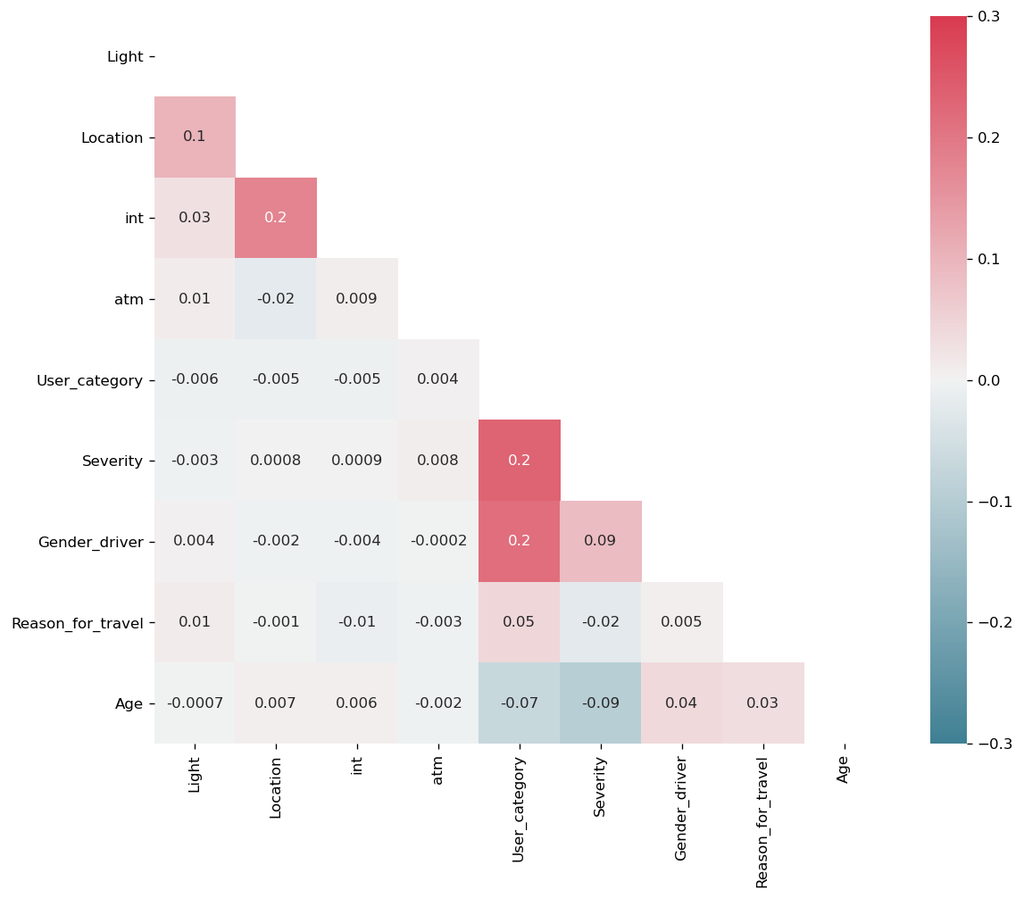

```python
#plot heatmap of df123 with numeric encodings, using selected columns

df123_sel = df123[['Light','Location','int','atm','User_category','Severity','Gender_driver','Reason_for_travel','Age']]
corr = df123_sel.corr()

plt.figure(figsize=(11,9))

#create mask to hide repetitive other half of heatmap to make it visually appealing
mask = np.triu(np.ones_like(corr, dtype=np.bool))

#create color map
cmap = sns.diverging_palette(220,8,as_cmap=True)

#plot heatmap
sns.heatmap(corr,cmap=cmap,mask=mask, annot=True, fmt='.1g',vmin=-0.3,vmax=0.3);
```

### Findings:

[figure not shown]

```python
fig, ax = plt.subplots(3, 4)
for i, col in enumerate(characteristics.select_dtypes(include=['float64', 'int64'])):
    sns.distplot(characteristics[col], ax=ax[i //4][i % 4])
```

# Data Description

```python
vehicles.info()
```

```
<class 'pandas.core.frame.DataFrame'>
RangeIndex: 100710 entries, 0 to 100709
Data columns (total 11 columns):
 #   Column            Non-Null Count   Dtype
---  ------            --------------   -----
 0   ID_Acc            100710 non-null  int64
 1   ID_veh            100710 non-null  object
 2   Vehicle_No        100710 non-null  object
 3   Flow_Direction    100710 non-null  int64
 4   Vehicle_category  100710 non-null  int64
 5   Fix_Obst_st       100710 non-null  int64
 6   Mov_Obst_st       100710 non-null  int64
 7   Shock_pt          100710 non-null  int64
 8   Maneuver          100710 non-null  int64
 9   motor             100710 non-null  int64
 10  No.of_occupants   892 non-null     float64
dtypes: float64(1), int64(8), object(2)
memory usage: 8.5+ MB
```

```python
vehicles.describe()
```

|  | ID_Acc | Flow_Direction | Vehicle_category | Fix_Obst_st | Mov_Obst_st | Shock_pt | Maneuver | motor | No.of_occupants |
| --- | --- | --- | --- | --- | --- | --- | --- | --- | --- |
| count | 1.007100e+05 | 100710.000000 | 100710.000000 | 100710.000000 | 100710.000000 | 100710.000000 | 100710.000000 | 100710.000000 | 892.000000 |
| mean | 2.019000e+11 | 1.557075 | 12.632817 | 0.990646 | 1.627098 | 2.926045 | 7.267401 | 1.171353 | 1.818386 |
| std | 1.697432e+04 | 0.833885 | 12.800755 | 3.088678 | 1.120068 | 2.421520 | 8.077319 | 1.112887 | 2.858931 |
| min | 2.019000e+11 | -1.000000 | 0.000000 | -1.000000 | -1.000000 | -1.000000 | -1.000000 | -1.000000 | 0.000000 |
| 25% | 2.019000e+11 | 1.000000 | 7.000000 | 0.000000 | 1.000000 | 1.000000 | 1.000000 | 1.000000 | 1.000000 |
| 50% | 2.019000e+11 | 1.000000 | 7.000000 | 0.000000 | 2.000000 | 2.000000 | 2.000000 | 1.000000 | 1.000000 |
| 75% | 2.019000e+11 | 2.000000 | 10.000000 | 0.000000 | 2.000000 | 4.000000 | 15.000000 | 1.000000 | 1.000000 |
| max | 2.019001e+11 | 3.000000 | 99.000000 | 17.000000 | 9.000000 | 9.000000 | 26.000000 | 6.000000 | 33.000000 |

```python
#unerwartete Zahlen für die Kategorien
vehicles["Vehicle_category"].unique()
```

```
array([ 7, 17, 33, 42, 30, 37, 32, 50, 38, 10,  1, 40, 15, 14, 99,  2, 80,
       34, 60, 31,  0, 21,  3, 13, 20, 43, 36, 39, 16, 35, 41],
      dtype=int64)
```

```python
df["Vehicle_No"].unique()
```

```
array(['B01', 'A01', 'C01', 'D01', 'E01', 'Z01', 'Y01', 'I01', 'T01',
       'O01', 'G01', 'F01', 'M01', 'LB01', 'H01', 'J01', 'K01', 'L01',
       'N01', 'W01', 'X01', 'U01', 'V01', 'Q01', 'MA01', 'CB01', '\\01',
       'VF01', 'P01'], dtype=object)
```

```python
vehicles.corr()
```

|  | ID_Acc | Flow_Direction | Vehicle_category | Fix_Obst_st | Mov_Obst_st | Shock_pt | Maneuver | motor | No.of_occupants |
| --- | --- | --- | --- | --- | --- | --- | --- | --- | --- |
| ID_Acc | 1.000000 | -0.004331 | 0.004000 | 0.004541 | 0.001722 | -0.000754 | 0.003393 | 0.008818 | 0.074580 |
| Flow_Direction | -0.004331 | 1.000000 | 0.001414 | 0.009730 | 0.014564 | 0.012535 | 0.037115 | 0.025257 | -0.034905 |
| Vehicle_category | 0.004000 | 0.001414 | 1.000000 | 0.011047 | -0.026008 | -0.024754 | -0.009838 | -0.044585 | 0.183555 |
| Fix_Obst_st | 0.004541 | 0.009730 | 0.011047 | 1.000000 | -0.328615 | -0.030390 | 0.007594 | -0.019914 | 0.243668 |
| Mov_Obst_st | 0.001722 | 0.014564 | -0.026008 | -0.328615 | 1.000000 | 0.028057 | 0.009547 | 0.015129 | -0.077708 |
| Shock_pt | -0.000754 | 0.012535 | -0.024754 | -0.030390 | 0.028057 | 1.000000 | 0.099523 | 0.018520 | -0.061628 |
| Maneuver | 0.003393 | 0.037115 | -0.009838 | 0.007594 | 0.009547 | 0.099523 | 1.000000 | 0.004503 | -0.036842 |
| motor | 0.008818 | 0.025257 | -0.044585 | -0.019914 | 0.015129 | 0.018520 | 0.004503 | 1.000000 | -0.011269 |
| No.of_occupants | 0.074580 | -0.034905 | 0.183555 | 0.243668 | -0.077708 | -0.061628 | -0.036842 | -0.011269 | 1.000000 |

```python
characteristics.info()
```

```
<class 'pandas.core.frame.DataFrame'>
Int64Index: 58713 entries, 0 to 58839
Data columns (total 16 columns):
 #   Column        Non-Null Count  Dtype
---  ------        --------------  -----
 0   ID_Acc        58713 non-null  object
 1   Day           58713 non-null  int32
 2   Month         58713 non-null  int32
 3   Year          58713 non-null  int32
 4   Time          58713 non-null  float64
 5   Light         58713 non-null  float64
 6   Department    58713 non-null  object
 7   Municipality  58713 non-null  object
 8   Location      58713 non-null  float64
 9   int           58713 non-null  float64
 10  atm           58713 non-null  float64
 11  col           58713 non-null  float64
 12  adr           58286 non-null  object
 13  lat           58713 non-null  float64
 14  long          58713 non-null  float64
 15  Date          58713 non-null  object
dtypes: float64(8), int32(3), object(5)
memory usage: 9.0+ MB
```

```python
characteristics.describe()
```

|  | Day | Month | Year | Time | Light | Location | int | atm | col | lat | long |
| --- | --- | --- | --- | --- | --- | --- | --- | --- | --- | --- | --- |
| count | 58713.000000 | 58713.000000 | 58713.0 | 58713.000000 | 58713.000000 | 58713.000000 | 58713.000000 | 58713.000000 | 58713.000000 | 5.871300e+04 | 5.871300e+04 |
| mean | 15.685964 | 6.688485 | 2019.0 | 0.576343 | 1.945021 | 1.645990 | 2.025480 | 1.617052 | 4.164717 | 4.458634e+08 | 2.864451e+07 |
| std | 8.720109 | 3.387156 | 0.0 | 0.230809 | 1.504425 | 0.478216 | 1.997358 | 1.677022 | 1.953664 | 1.182908e+08 | 1.871112e+08 |
| min | 1.000000 | 1.000000 | 2019.0 | 0.000000 | 1.000000 | 1.000000 | 1.000000 | -1.000000 | -1.000000 | -6.142566e+08 | -1.781574e+09 |
| 25% | 8.000000 | 4.000000 | 2019.0 | 0.402778 | 1.000000 | 1.000000 | 1.000000 | 1.000000 | 3.000000 | 4.478586e+08 | 1.410280e+07 |
| 50% | 16.000000 | 7.000000 | 2019.0 | 0.611111 | 1.000000 | 2.000000 | 1.000000 | 1.000000 | 3.000000 | 4.782554e+08 | 2.398705e+07 |
| 75% | 23.000000 | 10.000000 | 2019.0 | 0.756944 | 3.000000 | 2.000000 | 2.000000 | 1.000000 | 6.000000 | 4.885652e+08 | 4.829060e+07 |
| max | 31.000000 | 12.000000 | 2019.0 | 0.999306 | 5.000000 | 2.000000 | 9.000000 | 9.000000 | 7.000000 | 6.356807e+08 | 1.740234e+09 |

```python
characteristics["Department"].nunique()
```

```
107
```

```python
characteristics["Municipality"].nunique()
```

```
11421
```

```python
characteristics["adr"].nunique()
```

```
31934
```

```python
characteristics.corr()
```

|  | Day | Month | Year | Time | Light | Location | int | atm | col | lat | long |
| --- | --- | --- | --- | --- | --- | --- | --- | --- | --- | --- | --- |
| Day | 1.000000 | -0.028728 | NaN | 0.012906 | -0.001659 | -0.007582 | 0.005883 | -0.021215 | -0.008909 | 0.006442 | -0.006483 |
| Month | -0.028728 | 1.000000 | NaN | -0.001651 | 0.072005 | -0.013048 | -0.003484 | 0.044290 | -0.005558 | 0.010596 | -0.004740 |
| Year | NaN | NaN | NaN | NaN | NaN | NaN | NaN | NaN | NaN | NaN | NaN |
| Time | 0.012906 | -0.001651 | NaN | 1.000000 | 0.047715 | 0.038282 | 0.011553 | -0.027550 | -0.064728 | 0.026125 | -0.015139 |
| Light | -0.001659 | 0.072005 | NaN | 0.047715 | 1.000000 | 0.102918 | 0.029782 | 0.011705 | 0.065279 | -0.012123 | -0.008756 |
| Location | -0.007582 | -0.013048 | NaN | 0.038282 | 0.102918 | 1.000000 | 0.178256 | -0.020464 | 0.012809 | 0.020375 | 0.014357 |
| int | 0.005883 | -0.003484 | NaN | 0.011553 | 0.029782 | 0.178256 | 1.000000 | 0.008700 | -0.057744 | -0.008943 | -0.000432 |
| atm | -0.021215 | 0.044290 | NaN | -0.027550 | 0.011705 | -0.020464 | 0.008700 | 1.000000 | 0.029946 | 0.051378 | -0.001631 |
| col | -0.008909 | -0.005558 | NaN | -0.064728 | 0.065279 | 0.012809 | -0.057744 | 0.029946 | 1.000000 | 0.001420 | 0.021969 |
| lat | 0.006442 | 0.010596 | NaN | 0.026125 | -0.012123 | 0.020375 | -0.008943 | 0.051378 | 0.001420 | 1.000000 | -0.270771 |
| long | -0.006483 | -0.004740 | NaN | -0.015139 | -0.008756 | 0.014357 | -0.000432 | -0.001631 | 0.021969 | -0.270771 | 1.000000 |

```python
places.info()
```

```
<class 'pandas.core.frame.DataFrame'>
RangeIndex: 58840 entries, 0 to 58839
Data columns (total 18 columns):
 #   Column                     Non-Null Count  Dtype
---  ------                     --------------  -----
 0   ID_Acc                     58840 non-null  object
 1   road_cat                   58814 non-null  float64
 2   route_num                  55879 non-null  object
 3   road_index1                48068 non-null  float64
 4   road_index2                4167 non-null   object
 5   traffic_regime             55669 non-null  float64
 6   traffic_lanes              58164 non-null  float64
 7   reserved_lane              58145 non-null  float64
 8   prof                       58800 non-null  float64
 9   upstream_terminal          51517 non-null  float64
 10  distance_to_upstream       51215 non-null  float64
 11  plan                       58803 non-null  float64
 12  central_reservation_width  211 non-null    float64
 13  roadwidth_vehicles         372 non-null    float64
 14  surf                       58793 non-null  float64
 15  infra                      58769 non-null  float64
 16  situ                       58698 non-null  float64
 17  speed_limit                57933 non-null  float64
dtypes: float64(15), object(3)
memory usage: 8.1+ MB
```

```python
places.describe()
```

|  | road_cat | road_index1 | traffic_regime | traffic_lanes | reserved_lane | prof | upstream_terminal | distance_to_upstream | plan | central_reservation_width | roadwidth_vehicles | surf | infra | situ | speed_limit |
| --- | --- | --- | --- | --- | --- | --- | --- | --- | --- | --- | --- | --- | --- | --- | --- |
| count | 58814.000000 | 48068.000000 | 55669.000000 | 58164.000000 | 58145.000000 | 58800.000000 | 51517.000000 | 51215.000000 | 58803.000000 | 211.000000 | 372.000000 | 58793.000000 | 58769.000000 | 58698.000000 | 57933.000000 |
| mean | 3.347740 | 0.008758 | 1.980636 | 2.443247 | 0.149058 | 1.244184 | 19.138944 | 189.394709 | 1.305682 | 4.684360 | 42.054301 | 1.279251 | 0.881740 | 1.408344 | 60.854297 |
| std | 1.250984 | 0.137390 | 0.605018 | 1.401903 | 0.574300 | 0.558611 | 111.939088 | 314.454298 | 0.679804 | 16.141514 | 64.433320 | 0.855923 | 2.248355 | 1.241448 | 22.927331 |
| min | 1.000000 | 0.000000 | 1.000000 | 0.000000 | 0.000000 | 1.000000 | 0.000000 | 0.000000 | 1.000000 | 0.000000 | 2.400000 | 1.000000 | 0.000000 | 1.000000 | 0.000000 |
| 25% | 3.000000 | 0.000000 | 2.000000 | 2.000000 | 0.000000 | 1.000000 | 0.000000 | 0.000000 | 1.000000 | 0.000000 | 6.000000 | 1.000000 | 0.000000 | 1.000000 | 50.000000 |
| 50% | 3.000000 | 0.000000 | 2.000000 | 2.000000 | 0.000000 | 1.000000 | 0.000000 | 0.000000 | 1.000000 | 0.000000 | 14.000000 | 1.000000 | 0.000000 | 1.000000 | 50.000000 |
| 75% | 4.000000 | 0.000000 | 2.000000 | 3.000000 | 0.000000 | 1.000000 | 13.000000 | 336.000000 | 1.000000 | 2.000000 | 65.000000 | 1.000000 | 0.000000 | 1.000000 | 80.000000 |
| max | 9.000000 | 3.000000 | 4.000000 | 12.000000 | 3.000000 | 4.000000 | 8246.000000 | 7000.000000 | 4.000000 | 180.000000 | 730.000000 | 9.000000 | 9.000000 | 8.000000 | 800.000000 |

```python
places["route_num"].nunique()
```

```
14327
```

```python
places["road_index2"].nunique()
```

```
35
```

```python
places.corr()
```

|  | road_cat | road_index1 | traffic_regime | traffic_lanes | reserved_lane | prof | upstream_terminal | distance_to_upstream | plan | central_reservation_width | roadwidth_vehicles | surf | infra | situ | speed_limit |
| --- | --- | --- | --- | --- | --- | --- | --- | --- | --- | --- | --- | --- | --- | --- | --- |
| road_cat | 1.000000 | -0.010791 | -0.234258 | -0.336699 | 0.105897 | -0.054839 | -0.141676 | -0.376683 | -0.067906 | -0.241667 | -0.073371 | -0.016275 | 0.067499 | 0.013413 | -0.550833 |
| road_index1 | -0.010791 | 1.000000 | 0.001941 | -0.018139 | -0.000274 | 0.011224 | -0.000233 | 0.026981 | 0.016136 | NaN | 0.107575 | 0.001119 | 0.000611 | 0.019766 | 0.005711 |
| traffic_regime | -0.234258 | 0.001941 | 1.000000 | 0.416285 | -0.011752 | 0.012965 | 0.054572 | 0.133466 | -0.025168 | 0.414883 | 0.129317 | 0.019857 | -0.008784 | 0.007603 | 0.263552 |
| traffic_lanes | -0.336699 | -0.018139 | 0.416285 | 1.000000 | 0.092833 | -0.045793 | 0.047168 | 0.116969 | -0.073987 | 0.529070 | 0.205428 | 0.002034 | -0.034295 | -0.047602 | 0.329468 |
| reserved_lane | 0.105897 | -0.000274 | -0.011752 | 0.092833 | 1.000000 | -0.036195 | -0.017741 | -0.101499 | -0.066167 | -0.021323 | 0.084861 | -0.014498 | 0.065807 | 0.103653 | -0.103127 |
| prof | -0.054839 | 0.011224 | 0.012965 | -0.045793 | -0.036195 | 1.000000 | 0.014807 | 0.074363 | 0.220299 | -0.157947 | -0.080010 | 0.055322 | -0.001497 | 0.047196 | 0.049613 |
| upstream_terminal | -0.141676 | -0.000233 | 0.054572 | 0.047168 | -0.017741 | 0.014807 | 1.000000 | 0.086791 | 0.013903 | 0.411379 | 0.122277 | 0.010776 | -0.008756 | 0.022595 | 0.158091 |
| distance_to_upstream | -0.376683 | 0.026981 | 0.133466 | 0.116969 | -0.101499 | 0.074363 | 0.086791 | 1.000000 | 0.130987 | -0.095976 | -0.037358 | 0.032508 | -0.035617 | 0.099481 | 0.395538 |
| plan | -0.067906 | 0.016136 | -0.025168 | -0.073987 | -0.066167 | 0.220299 | 0.013903 | 0.130987 | 1.000000 | -0.101576 | -0.058645 | 0.093955 | 0.012562 | 0.107620 | 0.080356 |
| central_reservation_width | -0.241667 | NaN | 0.414883 | 0.529070 | -0.021323 | -0.157947 | 0.411379 | -0.095976 | -0.101576 | 1.000000 | 0.482302 | 0.015869 | 0.123493 | -0.093987 | 0.205641 |
| roadwidth_vehicles | -0.073371 | 0.107575 | 0.129317 | 0.205428 | 0.084861 | -0.080010 | 0.122277 | -0.037358 | -0.058645 | 0.482302 | 1.000000 | -0.029025 | 0.014564 | -0.041608 | 0.029691 |
| surf | -0.016275 | 0.001119 | 0.019857 | 0.002034 | -0.014498 | 0.055322 | 0.010776 | 0.032508 | 0.093955 | 0.015869 | -0.029025 | 1.000000 | 0.026011 | 0.051601 | 0.044036 |
| infra | 0.067499 | 0.000611 | -0.008784 | -0.034295 | 0.065807 | -0.001497 | -0.008756 | -0.035617 | 0.012562 | 0.123493 | 0.014564 | 0.026011 | 1.000000 | 0.024861 | -0.115345 |
| situ | 0.013413 | 0.019766 | 0.007603 | -0.047602 | 0.103653 | 0.047196 | 0.022595 | 0.099481 | 0.107620 | -0.093987 | -0.041608 | 0.051601 | 0.024861 | 1.000000 | 0.063105 |
| speed_limit | -0.550833 | 0.005711 | 0.263552 | 0.329468 | -0.103127 | 0.049613 | 0.158091 | 0.395538 | 0.080356 | 0.205641 | 0.029691 | 0.044036 | -0.115345 | 0.063105 | 1.000000 |

```python
drivers.info()
```

```
<class 'pandas.core.frame.DataFrame'>
RangeIndex: 132977 entries, 0 to 132976
Data columns (total 15 columns):
 #   Column             Non-Null Count   Dtype
---  ------             --------------   -----
 0   ID_Acc             132977 non-null  int64
 1   ID_veh             132977 non-null  object
 2   Vehicle_No         132977 non-null  object
 3   place              132977 non-null  int64
 4   User_category      132977 non-null  int64
 5   Severity           132977 non-null  int64
 6   Gender_driver      132977 non-null  int64
 7   DOB_driver         132977 non-null  int64
 8   Reason_for_travel  132977 non-null  int64
 9   Safety_equip_1     132977 non-null  int64
 10  Safety_equip_2     132977 non-null  int64
 11  Safety_equip_3     132977 non-null  int64
 12  Ped_loc            132977 non-null  int64
 13  Ped_act            132977 non-null  object
 14  Ped_acc            132977 non-null  int64
dtypes: int64(12), object(3)
memory usage: 15.2+ MB
```

```python
drivers.describe()
```

|  | ID_Acc | place | User_category | Severity | Gender_driver | DOB_driver | Reason_for_travel | Safety_equip_1 | Safety_equip_2 | Safety_equip_3 | Ped_loc | Ped_acc |
| --- | --- | --- | --- | --- | --- | --- | --- | --- | --- | --- | --- | --- |
| count | 1.329770e+05 | 132977.000000 | 132977.000000 | 132977.000000 | 132977.000000 | 132977.000000 | 132977.000000 | 132977.000000 | 132977.000000 | 132977.000000 | 132977.000000 | 132977.000000 |
| mean | 2.019000e+11 | 2.184754 | 1.352587 | 2.542635 | 1.320304 | 1980.079600 | 3.224279 | 2.179790 | 1.454282 | -0.913361 | -0.109267 | -0.810306 |
| std | 1.699444e+04 | 2.695724 | 0.630635 | 1.371815 | 0.466595 | 19.164625 | 2.667380 | 2.474627 | 3.284485 | 0.892062 | 1.247776 | 0.648306 |
| min | 2.019000e+11 | 1.000000 | 1.000000 | 1.000000 | 1.000000 | 1900.000000 | -1.000000 | -1.000000 | -1.000000 | -1.000000 | -1.000000 | -1.000000 |
| 25% | 2.019000e+11 | 1.000000 | 1.000000 | 1.000000 | 1.000000 | 1967.000000 | 0.000000 | 1.000000 | -1.000000 | -1.000000 | -1.000000 | -1.000000 |
| 50% | 2.019000e+11 | 1.000000 | 1.000000 | 3.000000 | 1.000000 | 1983.000000 | 4.000000 | 1.000000 | 0.000000 | -1.000000 | 0.000000 | -1.000000 |
| 75% | 2.019000e+11 | 2.000000 | 2.000000 | 4.000000 | 2.000000 | 1995.000000 | 5.000000 | 2.000000 | 3.000000 | -1.000000 | 0.000000 | -1.000000 |
| max | 2.019001e+11 | 10.000000 | 3.000000 | 4.000000 | 2.000000 | 2019.000000 | 9.000000 | 9.000000 | 9.000000 | 9.000000 | 9.000000 | 3.000000 |

```python
drivers.corr()
```

|  | ID_Acc | place | User_category | Severity | Gender_driver | DOB_driver | Reason_for_travel | Safety_equip_1 | Safety_equip_2 | Safety_equip_3 | Ped_loc | Ped_acc |
| --- | --- | --- | --- | --- | --- | --- | --- | --- | --- | --- | --- | --- |
| ID_Acc | 1.000000 | -0.003811 | -0.003250 | -0.000458 | -0.001111 | -0.003545 | 0.011626 | 0.007662 | -0.007761 | -0.000332 | 0.006282 | -0.007062 |
| place | -0.003811 | 1.000000 | 0.897206 | 0.216831 | 0.160247 | 0.047854 | 0.033686 | 0.317689 | -0.191436 | -0.018502 | 0.727779 | 0.848291 |
| User_category | -0.003250 | 0.897206 | 1.000000 | 0.233572 | 0.215451 | 0.074622 | 0.046290 | 0.274996 | -0.185828 | -0.022326 | 0.651889 | 0.764367 |
| Severity | -0.000458 | 0.216831 | 0.233572 | 1.000000 | 0.087076 | 0.094170 | -0.022635 | 0.164993 | 0.070478 | 0.032295 | 0.166668 | 0.210599 |
| Gender_driver | -0.001111 | 0.160247 | 0.215451 | 0.087076 | 1.000000 | -0.037238 | 0.005482 | -0.002102 | -0.061324 | -0.029454 | 0.092458 | 0.112675 |
| DOB_driver | -0.003545 | 0.047854 | 0.074622 | 0.094170 | -0.037238 | 1.000000 | -0.031978 | 0.037787 | 0.040501 | -0.010298 | -0.070246 | -0.038296 |
| Reason_for_travel | 0.011626 | 0.033686 | 0.046290 | -0.022635 | 0.005482 | -0.031978 | 1.000000 | -0.029863 | -0.007371 | 0.014409 | 0.033665 | -0.005803 |
| Safety_equip_1 | 0.007662 | 0.317689 | 0.274996 | 0.164993 | -0.002102 | 0.037787 | -0.029863 | 1.000000 | -0.082270 | 0.006556 | 0.277779 | 0.337097 |
| Safety_equip_2 | -0.007761 | -0.191436 | -0.185828 | 0.070478 | -0.061324 | 0.040501 | -0.007371 | -0.082270 | 1.000000 | 0.127000 | -0.203892 | -0.143277 |
| Safety_equip_3 | -0.000332 | -0.018502 | -0.022326 | 0.032295 | -0.029454 | -0.010298 | 0.014409 | 0.006556 | 0.127000 | 1.000000 | 0.019207 | -0.007223 |
| Ped_loc | 0.006282 | 0.727779 | 0.651889 | 0.166668 | 0.092458 | -0.070246 | 0.033665 | 0.277779 | -0.203892 | 0.019207 | 1.000000 | 0.779813 |
| Ped_acc | -0.007062 | 0.848291 | 0.764367 | 0.210599 | 0.112675 | -0.038296 | -0.005803 | 0.337097 | -0.143277 | -0.007223 | 0.779813 | 1.000000 |

# Datensatz zusammenfügen

Kurze Erklärung, wieso kein einfacher Merge funktioniert: bei den ersten beiden Datzensätzen wird die ID nicht als int64, sondern als object gespeichert, weil sie den vorhanden Speicherplatz für eine "C-long" übersteigt. Deshalb ist auch eine Umwandlung zu diesem dtype nicht möglich. Folgende Fehlermeldung kommt: *Python int too large to convert to C long*. Pandas gleift auf C zurück und dort sind keine so großen Zahlen möglich.

Ein merge ist auf Zeilen mit unterschiedlichen dtypes nicht möglich: *You are trying to merge on object and int64 columns. If you wish to proceed you should use pd.concat*. Wie uns die Fehlermeldung rät, benutzen wir pd.concat.

```python
# # Indexing the tables
characteristics = characteristics.set_index('ID_Acc')
places = places.set_index('ID_Acc')
drivers = drivers.set_index('ID_veh')
vehicles = vehicles.set_index('ID_veh')
```

```python
df_acc = pd.concat([characteristics, places.reindex(characteristics.index)], axis=1)
df_veh = pd.concat([drivers, vehicles.reindex(drivers.index)], axis=1)
```

```python
df_acc.loc[:, ~df_acc.columns.duplicated()]
df_acc.loc[df_acc.duplicated(keep=False)]
df_acc.duplicated()
```

```
ID_Acc
201900000001    False
201900000002    False
201900000003    False
201900000004    False
201900000005    False
                ...
201900058836    False
201900058837    False
201900058838    False
201900058839    False
201900058840    False
Length: 58713, dtype: bool
```

```python
df_veh
```

| ID_veh | ID_Acc | Vehicle_No | place | User_category | Severity | Gender_driver | DOB_driver | Reason_for_travel | Safety_equip_1 | Safety_equip_2 | ... | ID_Acc | Vehicle_No | Flow_Direction | Vehicle_category | Fix_Obst_st | Mov_Obst_st | Shock_pt | Maneuver | motor | No.of_occupants |
| --- | --- | --- | --- | --- | --- | --- | --- | --- | --- | --- | --- | --- | --- | --- | --- | --- | --- | --- | --- | --- | --- |
| 138 306 524 | 201900000001 | B01 | 2 | 2 | 4 | 2 | 2002 | 0 | 1 | 0 | ... | 201900000001 | B01 | 2 | 7 | 0 | 2 | 5 | 23 | 1 | NaN |
| 138 306 524 | 201900000001 | B01 | 1 | 1 | 4 | 2 | 1993 | 5 | 1 | 0 | ... | 201900000001 | B01 | 2 | 7 | 0 | 2 | 5 | 23 | 1 | NaN |
| 138 306 525 | 201900000001 | A01 | 1 | 1 | 1 | 1 | 1959 | 0 | 1 | 0 | ... | 201900000001 | A01 | 2 | 17 | 1 | 0 | 3 | 11 | 1 | NaN |
| 138 306 523 | 201900000002 | A01 | 1 | 1 | 4 | 2 | 1994 | 0 | 1 | 0 | ... | 201900000002 | A01 | 1 | 7 | 4 | 0 | 1 | 0 | 1 | NaN |
| 138 306 520 | 201900000003 | A01 | 1 | 1 | 1 | 1 | 1996 | 0 | 1 | 0 | ... | 201900000003 | A01 | 1 | 7 | 0 | 2 | 1 | 2 | 1 | NaN |
| ... | ... | ... | ... | ... | ... | ... | ... | ... | ... | ... | ... | ... | ... | ... | ... | ... | ... | ... | ... | ... | ... |
| 137 982 135 | 201900058837 | C01 | 1 | 1 | 4 | 2 | 1988 | 1 | 1 | 0 | ... | 201900058837 | C01 | 1 | 7 | 0 | 2 | 1 | 2 | 1 | NaN |
| 137 982 132 | 201900058838 | A01 | 1 | 1 | 4 | 1 | 1998 | 9 | 1 | 0 | ... | 201900058838 | A01 | 2 | 7 | 3 | 0 | 1 | 21 | 0 | NaN |
| 137 982 131 | 201900058839 | A01 | 1 | 1 | 3 | 1 | 1979 | 0 | 2 | 0 | ... | 201900058839 | A01 | 2 | 33 | 0 | 0 | 7 | 1 | 1 | NaN |
| 137 982 129 | 201900058840 | B01 | 1 | 1 | 4 | 1 | 1974 | 0 | 1 | 0 | ... | 201900058840 | B01 | 1 | 10 | 0 | 2 | 4 | 0 | 2 | NaN |
| 137 982 130 | 201900058840 | A01 | 1 | 1 | 1 | 1 | 1971 | 0 | 1 | -1 | ... | 201900058840 | A01 | 1 | 10 | 0 | 2 | 1 | 0 | 1 | NaN |

132977 rows × 24 columns

```python
df_acc = df_acc.loc[:, ~df_acc.columns.duplicated()]
df_veh = df_veh.loc[:, ~df_veh.columns.duplicated()]

df_veh.reset_index(drop=True, inplace=True)

df_veh.index = df_veh['ID_Acc'].astype('str')
df_veh = df_veh.drop(['ID_Acc'], axis=1)

df = pd.concat([df_acc.reindex(df_veh.index), df_veh], axis=1)
```

```python
df
```

| ID_Acc | Day | Month | Year | Time | Light | Department | Municipality | Location | int | atm | ... | Ped_act | Ped_acc | Flow_Direction | Vehicle_category | Fix_Obst_st | Mov_Obst_st | Shock_pt | Maneuver | motor | No.of_occupants |
| --- | --- | --- | --- | --- | --- | --- | --- | --- | --- | --- | --- | --- | --- | --- | --- | --- | --- | --- | --- | --- | --- |
| 201900000001 | 30.0 | 11.0 | 2019.0 | 0.062500 | 4.0 | 93 | 93053 | 1.0 | 1.0 | 1.0 | ... | -1 | -1 | 2 | 7 | 0 | 2 | 5 | 23 | 1 | NaN |
| 201900000001 | 30.0 | 11.0 | 2019.0 | 0.062500 | 4.0 | 93 | 93053 | 1.0 | 1.0 | 1.0 | ... | -1 | -1 | 2 | 7 | 0 | 2 | 5 | 23 | 1 | NaN |
| 201900000001 | 30.0 | 11.0 | 2019.0 | 0.062500 | 4.0 | 93 | 93053 | 1.0 | 1.0 | 1.0 | ... | -1 | -1 | 2 | 17 | 1 | 0 | 3 | 11 | 1 | NaN |
| 201900000002 | 30.0 | 11.0 | 2019.0 | 0.118056 | 3.0 | 93 | 93066 | 1.0 | 1.0 | 1.0 | ... | -1 | -1 | 1 | 7 | 4 | 0 | 1 | 0 | 1 | NaN |
| 201900000003 | 28.0 | 11.0 | 2019.0 | 0.635417 | 1.0 | 92 | 92036 | 1.0 | 1.0 | 1.0 | ... | 0 | -1 | 1 | 7 | 0 | 2 | 1 | 2 | 1 | NaN |
| ... | ... | ... | ... | ... | ... | ... | ... | ... | ... | ... | ... | ... | ... | ... | ... | ... | ... | ... | ... | ... | ... |
| 201900058837 | 27.0 | 11.0 | 2019.0 | 0.326389 | 1.0 | 67 | 67482 | 1.0 | 1.0 | 8.0 | ... | -1 | -1 | 1 | 7 | 0 | 2 | 1 | 2 | 1 | NaN |
| 201900058838 | 30.0 | 11.0 | 2019.0 | 0.111806 | 4.0 | 94 | 94021 | 1.0 | 1.0 | 1.0 | ... | -1 | -1 | 2 | 7 | 3 | 0 | 1 | 21 | 0 | NaN |
| 201900058839 | 30.0 | 11.0 | 2019.0 | 0.638889 | 1.0 | 78 | 78640 | 1.0 | 1.0 | 1.0 | ... | -1 | -1 | 2 | 33 | 0 | 0 | 7 | 1 | 1 | NaN |
| 201900058840 | 29.0 | 11.0 | 2019.0 | 0.868056 | 3.0 | 92 | 92047 | 1.0 | 1.0 | 1.0 | ... | 0 | -1 | 1 | 10 | 0 | 2 | 4 | 0 | 2 | NaN |
| 201900058840 | 29.0 | 11.0 | 2019.0 | 0.868056 | 3.0 | 92 | 92047 | 1.0 | 1.0 | 1.0 | ... | 0 | -1 | 1 | 10 | 0 | 2 | 1 | 0 | 1 | NaN |

132977 rows × 53 columns

```python
df.info()
```

```
<class 'pandas.core.frame.DataFrame'>
Index: 132977 entries, 201900000001 to 201900058840
Data columns (total 53 columns):
 #   Column                     Non-Null Count   Dtype
---  ------                     --------------   -----
 0   Day                        132714 non-null  float64
 1   Month                      132714 non-null  float64
 2   Year                       132714 non-null  float64
 3   Time                       132714 non-null  float64
 4   Light                      132714 non-null  float64
 5   Department                 132714 non-null  object
 6   Municipality               132714 non-null  object
 7   Location                   132714 non-null  float64
 8   int                        132714 non-null  float64
 9   atm                        132714 non-null  float64
```

[output cut: 45 more lines]

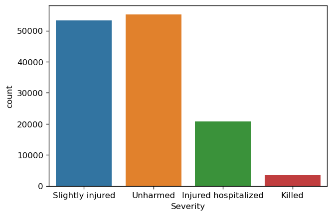

```python
#Verteilung der Targetspalte
sns.countplot(df['Severity'].map({1: 'Unharmed',
                                  2: 'Killed',
                                  3: 'Injured hospitalized',
                                  4: 'Slightly injured'
                                  }))
```

```python
# Adding week day column
df["Date"] = pd.to_datetime(df["Date"], errors='coerce')
df["DayOfWeek"] = df["Date"].dt.day_name()
df
```

| ID_Acc | Day | Month | Year | Time | Light | Department | Municipality | Location | int | atm | ... | Ped_acc | Flow_Direction | Vehicle_category | Fix_Obst_st | Mov_Obst_st | Shock_pt | Maneuver | motor | No.of_occupants | DayOfWeek |
| --- | --- | --- | --- | --- | --- | --- | --- | --- | --- | --- | --- | --- | --- | --- | --- | --- | --- | --- | --- | --- | --- |
| 201900000001 | 30.0 | 11.0 | 2019.0 | 0.062500 | 4.0 | 93 | 93053 | 1.0 | 1.0 | 1.0 | ... | -1 | 2 | 7 | 0 | 2 | 5 | 23 | 1 | NaN | Saturday |
| 201900000001 | 30.0 | 11.0 | 2019.0 | 0.062500 | 4.0 | 93 | 93053 | 1.0 | 1.0 | 1.0 | ... | -1 | 2 | 7 | 0 | 2 | 5 | 23 | 1 | NaN | Saturday |
| 201900000001 | 30.0 | 11.0 | 2019.0 | 0.062500 | 4.0 | 93 | 93053 | 1.0 | 1.0 | 1.0 | ... | -1 | 2 | 17 | 1 | 0 | 3 | 11 | 1 | NaN | Saturday |
| 201900000002 | 30.0 | 11.0 | 2019.0 | 0.118056 | 3.0 | 93 | 93066 | 1.0 | 1.0 | 1.0 | ... | -1 | 1 | 7 | 4 | 0 | 1 | 0 | 1 | NaN | Saturday |
| 201900000003 | 28.0 | 11.0 | 2019.0 | 0.635417 | 1.0 | 92 | 92036 | 1.0 | 1.0 | 1.0 | ... | -1 | 1 | 7 | 0 | 2 | 1 | 2 | 1 | NaN | Thursday |
| ... | ... | ... | ... | ... | ... | ... | ... | ... | ... | ... | ... | ... | ... | ... | ... | ... | ... | ... | ... | ... | ... |
| 201900058837 | 27.0 | 11.0 | 2019.0 | 0.326389 | 1.0 | 67 | 67482 | 1.0 | 1.0 | 8.0 | ... | -1 | 1 | 7 | 0 | 2 | 1 | 2 | 1 | NaN | Wednesday |
| 201900058838 | 30.0 | 11.0 | 2019.0 | 0.111806 | 4.0 | 94 | 94021 | 1.0 | 1.0 | 1.0 | ... | -1 | 2 | 7 | 3 | 0 | 1 | 21 | 0 | NaN | Saturday |
| 201900058839 | 30.0 | 11.0 | 2019.0 | 0.638889 | 1.0 | 78 | 78640 | 1.0 | 1.0 | 1.0 | ... | -1 | 2 | 33 | 0 | 0 | 7 | 1 | 1 | NaN | Saturday |
| 201900058840 | 29.0 | 11.0 | 2019.0 | 0.868056 | 3.0 | 92 | 92047 | 1.0 | 1.0 | 1.0 | ... | -1 | 1 | 10 | 0 | 2 | 4 | 0 | 2 | NaN | Friday |
| 201900058840 | 29.0 | 11.0 | 2019.0 | 0.868056 | 3.0 | 92 | 92047 | 1.0 | 1.0 | 1.0 | ... | -1 | 1 | 10 | 0 | 2 | 1 | 0 | 1 | NaN | Friday |

132977 rows × 54 columns

```python
df.select_dtypes(include=['float64', 'int64']).columns
```

```
Index(['Day', 'Month', 'Year', 'Time', 'Light', 'Location', 'int', 'atm',
       'col', 'lat', 'long', 'road_cat', 'road_index1', 'traffic_regime',
       'traffic_lanes', 'reserved_lane', 'prof', 'upstream_terminal',
       'distance_to_upstream', 'plan', 'central_reservation_width',
       'roadwidth_vehicles', 'surf', 'infra', 'situ', 'speed_limit', 'place',
       'User_category', 'Severity', 'Gender_driver', 'DOB_driver',
       'Reason_for_travel', 'Safety_equip_1', 'Safety_equip_2',
       'Safety_equip_3', 'Ped_loc', 'Ped_acc', 'Flow_Direction',
       'Vehicle_category', 'Fix_Obst_st', 'Mov_Obst_st', 'Shock_pt',
       'Maneuver', 'motor', 'No.of_occupants'],
      dtype='object')
```

```python
#gehört eher nach oben
df_faher = df[df["place"] == 1]
y = df_faher["DOB_driver"]
```

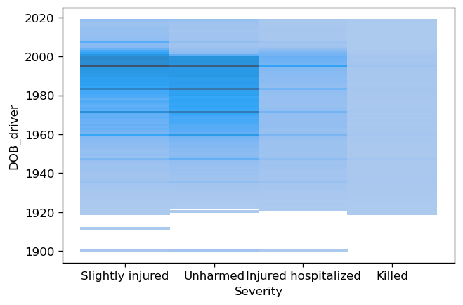

```python
sns.histplot(y = df["DOB_driver"],x = df["Severity"].map({1: 'Unharmed',
                                  2: 'Killed',
                                  3: 'Injured hospitalized',
                                  4: 'Slightly injured'
                                  }))
```

```python
#metric_columns = df.select_dtypes(include=['float64', 'int64']).columns

#fig, ax = plt.subplots(len(metric_columns))
#for i, col in enumerate(metric_columns):
#    sns.distplot(df[col], ax=ax[i])
```

# Umgang mit fehlenden Werten

```python
a = pd.DataFrame(
    np.transpose(
        np.array(
                (df.columns, round(df.isna().sum()
                / df.shape[0], 4)), dtype=object,)),columns=['features', 'missing_rate'])
a
```

|  | features | missing_rate |
| --- | --- | --- |
| 0 | Day | 0.002 |
| 1 | Month | 0.002 |
| 2 | Year | 0.002 |
| 3 | Time | 0.002 |
| 4 | Light | 0.002 |
| 5 | Department | 0.002 |
| 6 | Municipality | 0.002 |
| 7 | Location | 0.002 |
| 8 | int | 0.002 |
| 9 | atm | 0.002 |
| 10 | col | 0.002 |
| 11 | adr | 0.0097 |
| 12 | lat | 0.002 |
| 13 | long | 0.002 |
| 14 | Date | 0.002 |
| 15 | road_cat | 0.002 |
| 16 | route_num | 0.0464 |
| 17 | road_index1 | 0.1863 |
| 18 | road_index2 | 0.927 |
| 19 | traffic_regime | 0.0523 |
| 20 | traffic_lanes | 0.0125 |
| 21 | reserved_lane | 0.0127 |
| 22 | prof | 0.0022 |
| 23 | upstream_terminal | 0.1204 |
| 24 | distance_to_upstream | 0.1255 |
| 25 | plan | 0.0021 |
| 26 | central_reservation_width | 0.9965 |
| 27 | roadwidth_vehicles | 0.9938 |
| 28 | surf | 0.0023 |
| 29 | infra | 0.0027 |
| 30 | situ | 0.0037 |
| 31 | speed_limit | 0.0162 |
| 32 | Vehicle_No | 0.0 |
| 33 | place | 0.0 |
| 34 | User_category | 0.0 |
| 35 | Severity | 0.0 |
| 36 | Gender_driver | 0.0 |
| 37 | DOB_driver | 0.0 |
| 38 | Reason_for_travel | 0.0 |
| 39 | Safety_equip_1 | 0.0 |
| 40 | Safety_equip_2 | 0.0 |
| 41 | Safety_equip_3 | 0.0 |
| 42 | Ped_loc | 0.0 |
| 43 | Ped_act | 0.0 |
| 44 | Ped_acc | 0.0 |
| 45 | Flow_Direction | 0.0 |
| 46 | Vehicle_category | 0.0 |
| 47 | Fix_Obst_st | 0.0 |
| 48 | Mov_Obst_st | 0.0 |
| 49 | Shock_pt | 0.0 |
| 50 | Maneuver | 0.0 |
| 51 | motor | 0.0 |
| 52 | No.of_occupants | 0.9859 |
| 53 | DayOfWeek | 0.002 |

Bei den Umfallcharakteristika fehlen nur 0,2% der Werte. Diese Zeilen werden gelöscht. Außerdem werden die Features, bei denen mehr als 30% der Werte fehlen ebenfalls gelöscht.

```python
df["distance_to_upstream"].describe()
```

```
count    116286.000000
mean        199.610822
std         318.521151
min           0.000000
25%           0.000000
50%           0.000000
75%         399.000000
max        7000.000000
Name: distance_to_upstream, dtype: float64
```

```python
df["distance_to_upstream"].quantile(0.58) #58% aller Werte unter 1, 12% nan -> delete column
```

```
1.0
```

```python
df = df.drop(columns = ["Date", "road_index1", "road_index2", "upstream_terminal","distance_to_upstream", "central_reservation_width",
                        "roadwidth_vehicles", "No.of_occupants", "Year","Safety_equip_3"])
```

```python
df = df.loc[df["Day"].notna()] #fehlende Werte in diesen Spalten sind nicht sinnvoll aufzufüllen, deswegen Zeilen löschen
df = df.loc[df["prof"].notna()]
df = df.loc[df["plan"].notna()]
df = df.loc[df["surf"].notna()]
df = df.loc[df["adr"].notna()]
df = df.loc[df["route_num"].notna()]
df = df.loc[df["speed_limit"].notna()]
```

```python
a = pd.DataFrame(
    np.transpose(
        np.array(
                (df.columns, round(df.isna().sum()
                / df.shape[0], 4)), dtype=object,)),columns=['features', 'missing_rate'])
a
```

|  | features | missing_rate |
| --- | --- | --- |
| 0 | Day | 0.0 |
| 1 | Month | 0.0 |
| 2 | Time | 0.0 |
| 3 | Light | 0.0 |
| 4 | Department | 0.0 |
| 5 | Municipality | 0.0 |
| 6 | Location | 0.0 |
| 7 | int | 0.0 |
| 8 | atm | 0.0 |
| 9 | col | 0.0 |
| 10 | adr | 0.0 |
| 11 | lat | 0.0 |
| 12 | long | 0.0 |
| 13 | road_cat | 0.0 |
| 14 | route_num | 0.0 |
| 15 | traffic_regime | 0.0486 |
| 16 | traffic_lanes | 0.0063 |
| 17 | reserved_lane | 0.0068 |
| 18 | prof | 0.0 |
| 19 | plan | 0.0 |
| 20 | surf | 0.0 |
| 21 | infra | 0.0006 |
| 22 | situ | 0.0017 |
| 23 | speed_limit | 0.0 |
| 24 | Vehicle_No | 0.0 |
| 25 | place | 0.0 |
| 26 | User_category | 0.0 |
| 27 | Severity | 0.0 |
| 28 | Gender_driver | 0.0 |
| 29 | DOB_driver | 0.0 |
| 30 | Reason_for_travel | 0.0 |
| 31 | Safety_equip_1 | 0.0 |
| 32 | Safety_equip_2 | 0.0 |
| 33 | Ped_loc | 0.0 |
| 34 | Ped_act | 0.0 |
| 35 | Ped_acc | 0.0 |
| 36 | Flow_Direction | 0.0 |
| 37 | Vehicle_category | 0.0 |
| 38 | Fix_Obst_st | 0.0 |
| 39 | Mov_Obst_st | 0.0 |
| 40 | Shock_pt | 0.0 |
| 41 | Maneuver | 0.0 |
| 42 | motor | 0.0 |
| 43 | DayOfWeek | 0.0 |

# Imputation

```python
df["traffic_regime"].unique() #Einbahn, normal -> wenn impute dann ersetzen mit 2.0, d.h. bidirektional
```

```
array([ 3.,  1.,  2., nan,  4.])
```

```python
df["traffic_regime"].value_counts() #meiste ist bedirektional, dann einbahnstraße, dann Feldweg
```

```
2.0    74322
1.0    22322
3.0    20901
4.0      814
Name: traffic_regime, dtype: int64
```

```python
df["traffic_regime"].median()
```

```
2.0
```

```python
df['traffic_regime'] = df['traffic_regime'].fillna(2.0) #impute with modus = median. später alle Spalten auf einmal
```

```python
df["traffic_regime"].value_counts()
```

```
2.0    80372
1.0    22322
3.0    20901
4.0      814
Name: traffic_regime, dtype: int64
```

```python
df["traffic_lanes"].unique()
```

```
array([10.,  2.,  8.,  5.,  3.,  4.,  6.,  1.,  7.,  0., nan,  9., 11.,
       12.])
```

```python
df["traffic_lanes"].value_counts() #most common: 2 lanes #impute with
```

```
2.0     72702
4.0     16748
1.0     11191
3.0     10584
6.0      4033
0.0      3039
5.0      2584
8.0      1337
7.0       531
10.0      416
9.0       287
11.0       94
12.0       75
Name: traffic_lanes, dtype: int64
```

```python
df['traffic_lanes'] = df['traffic_lanes'].fillna(2) #impute with modus = mediann = 2
```

```python
df["traffic_lanes"].value_counts()
```

```
2.0     73490
4.0     16748
1.0     11191
3.0     10584
6.0      4033
0.0      3039
5.0      2584
8.0      1337
7.0       531
10.0      416
9.0       287
11.0       94
12.0       75
Name: traffic_lanes, dtype: int64
```

```python
df["reserved_lane"].unique()
```

```
array([ 0.,  1.,  3.,  2., nan])
```

```python
df["reserved_lane"].value_counts() #most common: 0 means not applicable #impute with 0 = modus = mean = most unmarked
```

```
0.0    114076
1.0      3892
3.0      3757
2.0      1839
Name: reserved_lane, dtype: int64
```

```python
df['reserved_lane'] = df['reserved_lane'].fillna(0) #impute with modus = mediann = 0
```

```python
df["infra"].unique()
```

```
array([ 2.,  0.,  9.,  1.,  5.,  4.,  6.,  3.,  8., nan,  7.])
```

```python
df["infra"].value_counts() #most common: 0 means no infrastructure #impute with 0 = modus = mean = most unmarked
```

```
0.0    103125
5.0      7502
9.0      4568
2.0      2584
3.0      2020
1.0      1781
8.0      1099
6.0      1039
4.0       518
7.0        99
Name: infra, dtype: int64
```

```python
df['infra'] = df['infra'].fillna(0) #impute with modus = median = 0, most unmarked
```

```python
df["infra"].value_counts()
```

```
0.0    103199
5.0      7502
9.0      4568
2.0      2584
3.0      2020
1.0      1781
8.0      1099
6.0      1039
4.0       518
7.0        99
Name: infra, dtype: int64
```

```python
df["situ"].value_counts() #most common: 1 means no special situation #impute with 1 = modus = mean = most unmarked
```

```
1.0    111037
3.0      6789
2.0      1953
8.0      1589
4.0       988
5.0       940
6.0       903
Name: situ, dtype: int64
```

```python
df['situ'] = df['situ'].fillna(1.0) #impute with modus = median = 0, most unmarked
```

```python
df["situ"].value_counts()
```

```
1.0    111247
3.0      6789
2.0      1953
8.0      1589
4.0       988
5.0       940
6.0       903
Name: situ, dtype: int64
```

```python
df['speed_limit'].value_counts() #alles unter 7 wird zu 7, alles über 500 wird zu 500 und heißt kein limit
#fehlende werte löschen (1,4% der Daten)
```

```
50.0     68444
80.0     19217
70.0      9694
90.0      8737
30.0      7667
110.0     5624
130.0     3571
60.0       462
20.0       286
10.0       210
40.0       109
15.0        68
5.0         56
45.0        46
2.0         44
500.0       35
100.0       30
1.0         23
25.0        20
3.0         14
6.0         14
35.0         9
4.0          7
700.0        4
65.0         4
42.0         4
7.0          2
12.0         2
120.0        2
0.0          2
600.0        1
800.0        1
Name: speed_limit, dtype: int64
```

```python
df.loc[(df["speed_limit"]  <7), "speed_limit"]= 7
df.loc[(df["speed_limit"]  >300), "speed_limit"]= 300
```

```python
df['speed_limit'].value_counts()
```

```
50.0     68444
80.0     19217
70.0      9694
90.0      8737
30.0      7667
110.0     5624
130.0     3571
60.0       462
20.0       286
10.0       210
7.0        162
40.0       109
15.0        68
45.0        46
300.0       41
100.0       30
25.0        20
35.0         9
65.0         4
42.0         4
12.0         2
120.0        2
Name: speed_limit, dtype: int64
```

```python
df.info()
```

```
<class 'pandas.core.frame.DataFrame'>
Index: 124409 entries, 201900000001 to 201900058840
Data columns (total 44 columns):
 #   Column             Non-Null Count   Dtype
---  ------             --------------   -----
 0   Day                124409 non-null  float64
 1   Month              124409 non-null  float64
 2   Time               124409 non-null  float64
 3   Light              124409 non-null  float64
 4   Department         124409 non-null  object
 5   Municipality       124409 non-null  object
 6   Location           124409 non-null  float64
 7   int                124409 non-null  float64
 8   atm                124409 non-null  float64
 9   col                124409 non-null  float64
```

[output cut: 36 more lines]

```python
df["Ped_act"].unique()
```

```
array(['-1', '0', '3', '2', '1', 'B', '4', '9', '5', 'A', '8', '6', '7'],
      dtype=object)
```

```python
df["Ped_act"].value_counts()
```

```
0     88482
-1    25806
3      7550
1       617
9       580
5       401
B       398
2       277
4       152
A        97
6        22
7        17
8        10
Name: Ped_act, dtype: int64
```

```python
df = df[df["Ped_act"] != '7']
df = df[df["Ped_act"] != '8']
df.loc[(df["Ped_act"] =='A'), "Ped_act"]= 7
df.loc[(df["Ped_act"] =='B'), "Ped_act"]= 8
```

```python
df["Ped_act"]=df["Ped_act"].astype(int)
```

```python
#####Coding sometimes starts with -1 (unknown), sometimes with 0 (not assigned) or 1 (proper category)
```

```python
df.iloc[:,30:].describe()
#kodierung mit -1 bei reason for travel (-1 und 0 not assigned)
# safety equip (-1: unbekannt, 8: not determinable, 9: others)
# safety equip2 (-1: unbekannt, 8: not determinable, 9: others)
# ped_loc (-1: unbekannt, 9 inconnu)
# ped_act (-1: unbekannt, 0 nicht zugewiesen oder ohne objekt, 9: others)
#ped_acc (-1: unbekannt)
#flow direction (-1: not assigned, 0:unknown)
# fixed obst (-1: unknown, 0: no object)
#mov_obst (-1: not assigned, 0: none, 9: other)
#shock_pt (-1: not assigned, 0:none )
#maneuver (-1: not assigned, 0: unknown, 26: other)
#motor (-1: not assigned, 0:unknown, 6: other)
```

|  | Reason_for_travel | Safety_equip_1 | Safety_equip_2 | Ped_loc | Ped_act | Ped_acc | Flow_Direction | Vehicle_category | Fix_Obst_st | Mov_Obst_st | Shock_pt | Maneuver | motor |
| --- | --- | --- | --- | --- | --- | --- | --- | --- | --- | --- | --- | --- | --- |
| count | 124382.000000 | 124382.000000 | 124382.000000 | 124382.000000 | 124382.000000 | 124382.000000 | 124382.000000 | 124382.000000 | 124382.000000 | 124382.000000 | 124382.000000 | 124382.000000 | 124382.000000 |
| mean | 3.206726 | 2.201034 | 1.536155 | -0.133918 | 0.079135 | -0.815592 | 1.548600 | 12.266325 | 1.095786 | 1.553271 | 2.923711 | 7.241289 | 1.147996 |
| std | 2.673199 | 2.480861 | 3.306909 | 1.233271 | 1.220090 | 0.639251 | 0.807621 | 12.309099 | 3.227583 | 1.067302 | 2.390162 | 8.121718 | 1.042005 |
| min | -1.000000 | -1.000000 | -1.000000 | -1.000000 | -1.000000 | -1.000000 | -1.000000 | 0.000000 | -1.000000 | -1.000000 | -1.000000 | -1.000000 | -1.000000 |
| 25% | 0.000000 | 1.000000 | -1.000000 | -1.000000 | 0.000000 | -1.000000 | 1.000000 | 7.000000 | 0.000000 | 1.000000 | 1.000000 | 1.000000 | 1.000000 |
| 50% | 4.000000 | 1.000000 | 0.000000 | 0.000000 | 0.000000 | -1.000000 | 1.000000 | 7.000000 | 0.000000 | 2.000000 | 2.000000 | 2.000000 | 1.000000 |
| 75% | 5.000000 | 2.000000 | 4.000000 | 0.000000 | 0.000000 | -1.000000 | 2.000000 | 10.000000 | 0.000000 | 2.000000 | 4.000000 | 15.000000 | 1.000000 |
| max | 9.000000 | 9.000000 | 9.000000 | 9.000000 | 9.000000 | 3.000000 | 3.000000 | 99.000000 | 17.000000 | 9.000000 | 9.000000 | 26.000000 | 6.000000 |

```python
#change -1 (not assigned) values where it makes sense (mostly to unknown)
df.loc[(df["Reason_for_travel"] == -1), "Reason_for_travel"]= 0 #both were the same
df.loc[(df["Safety_equip_1"] == -1), "Safety_equip_1"]= 8 #change to not deterrminable
df.loc[(df["Safety_equip_2"] == -1), "Safety_equip_2"]= 8 #change to not deterrminable
df.loc[(df["Ped_loc"] == -1), "Ped_loc"]= 9 #9 was also unknown
#df.loc[(df["Ped_acc"] == -1), "Ped_acc"]= 0 #just changed the value, value 0 did not exist before
df.loc[(df["Flow_Direction"] == -1), "Flow_Direction"]= 0 # changed to unknown
df.loc[(df["Maneuver"] == -1), "Maneuver"]= 0 # changed to unknown
df.loc[(df["motor"] == -1), "motor"]= 0 # changed to unknown
```

```python
df["Ped_loc"].unique()
```

```
array([9, 0, 2, 3, 1, 5, 4, 8, 6, 7], dtype=int64)
```

# encoding of string variables

```python
from sklearn.preprocessing import LabelEncoder
def encoding(df):
    label = LabelEncoder()
    for c in df.select_dtypes("object"):
        df[c]=df[c].astype(str)
        df[c]=label.fit_transform(df[c])
    return df

df = encoding(df)
```

```python
df.info()
```

```
<class 'pandas.core.frame.DataFrame'>
Index: 124382 entries, 201900000001 to 201900058840
Data columns (total 44 columns):
 #   Column             Non-Null Count   Dtype
---  ------             --------------   -----
 0   Day                124382 non-null  float64
 1   Month              124382 non-null  float64
 2   Time               124382 non-null  float64
 3   Light              124382 non-null  float64
 4   Department         124382 non-null  int32
 5   Municipality       124382 non-null  int32
 6   Location           124382 non-null  float64
 7   int                124382 non-null  float64
 8   atm                124382 non-null  float64
 9   col                124382 non-null  float64
```

[output cut: 36 more lines]

# Dataset contains only floats and integers, no missing values

```python
#df.to_csv('accidents2019.csv') #export dataframe
```

```python
#mydata = pd.read_csv('accidents2019.csv')
#mydata.info()
```